# The Full House Model for cross-era comparisons of baseball players (results and fun digressions version 2.0)

Daniel J. Eck and Shen Yan and Adrian Burgos Jr. and Christopher Kinson

We introduce version 2.0 of our Full House Model for comparing baseball players across eras. This document is meant to provide readers with new top all-time lists and many other interesting findings through the lens of era-adjusted statistics. Although casual and fun in nature, this document will be complicated and at times counter to one’s intuition. It is not necessarily meant to be digested in one sitting. Here is a list of topics:

- Top 25 rankings by era-adjusted bWAR (ebWAR), era-adjusted fWAR (efWAR), and the average of the two (we will call it eWAR)
- Top 25 rankings by era-adjusted JAWS
- Top rankings list of batters by several era-adjusted statistics
- Top rankings list of pitchers by several era-adjusted statistics
- A brief look at historic performances from the 2022 baseball season
- Mike Trout’s career
- Max Scherzer and a comparison with Tom Seaver
- CC Sabathia’s career
- WAR and its usage in HOF discussions
- Mark Buehrle’s career
- Luis Tiant’s career
- A comparison with Joe Posnanski’s The Baseball 100
- A comparison with Baseball Egg and the The 100 Greatest lists
- A comparison with ESPN’s top 100 list
- A commentary on Christina Kahrl’s insightful work
- A comprehensive contextual evaluation of Ted Williams’s career

This document will revisit some of the findings and analyses in our original series of articles, most notably the first and second parts of our original three-part series ([article I](https://htmlpreview.github.io/?https://github.com/ecklab/era-adjustment-app-supplement/blob/main/article_I.html) and [article II](https://htmlpreview.github.io/?https://github.com/ecklab/era-adjustment-app-supplement/blob/main/article_II.html)). Anyone familiar with our prior works should note that we apologize to Jeff Passan. Some, but not all, of his takes have been vindicated in version 2.0.

Anyone who desires a more rigorous look under the hood of Full House Modeling can find what they are looking for [here](https://github.com/ecklab/era-adjustment-app-supplement/blob/main/README.md).

We now present new top 25 all-time lists according to ebWAR, efWAR, and eWAR (average of ebWAR and efWAR). Top 100 ranking lists by ebWAR and efWAR are on our website.

| rank | name | ebWAR | rank | name | efWAR | rank | name | eWAR |
| --- | --- | --- | --- | --- | --- | --- | --- | --- |
| 1 | Barry Bonds | 153.89 | 1 | Barry Bonds | 145.24 | 1 | Barry Bonds | 149.56 |
| 2 | Roger Clemens | 145.88 | 2 | Roger Clemens | 141.25 | 2 | Roger Clemens | 143.56 |
| 3 | Willie Mays | 144.08 | 3 | Willie Mays | 135.39 | 3 | Willie Mays | 139.74 |
| 4 | Babe Ruth | 137.98 | 4 | Henry Aaron | 128.05 | 4 | Henry Aaron | 131.82 |
| 5 | Henry Aaron | 135.60 | 5 | Greg Maddux | 120.73 | 5 | Babe Ruth | 129.13 |
| 6 | Alex Rodriguez | 120.29 | 6 | Babe Ruth | 120.28 | 6 | Greg Maddux | 117.19 |
| 7 | Stan Musial | 119.51 | 7 | Stan Musial | 113.03 | 7 | Stan Musial | 116.27 |
| 8 | Ty Cobb | 114.48 | 8 | Alex Rodriguez | 110.30 | 8 | Alex Rodriguez | 115.30 |
| 9 | Greg Maddux | 113.66 | 9 | Randy Johnson | 109.77 | 9 | Ty Cobb | 111.62 |
| 10 | Albert Pujols | 111.86 | 10 | Ty Cobb | 108.77 | 10 | Randy Johnson | 110.29 |
| 11 | Randy Johnson | 110.81 | 11 | Nolan Ryan | 108.30 | 11 | Mike Schmidt | 108.00 |
| 12 | Mike Schmidt | 109.58 | 12 | Ted Williams | 107.75 | 12 | Ted Williams | 107.81 |
| 13 | Rickey Henderson | 109.08 | 13 | Mike Schmidt | 106.41 | 13 | Rickey Henderson | 106.49 |
| 14 | Ted Williams | 107.86 | 14 | Rickey Henderson | 103.90 | 14 | Albert Pujols | 104.60 |
| 15 | Tom Seaver | 104.31 | 15 | Bert Blyleven | 101.82 | 15 | Lefty Grove | 100.67 |
| 16 | Lefty Grove | 102.54 | 16 | Steve Carlton | 100.34 | 16 | Bert Blyleven | 99.75 |
| 17 | Tris Speaker | 102.26 | 17 | Lefty Grove | 98.80 | 17 | Tris Speaker | 98.69 |
| 18 | Justin Verlander | 100.23 | 18 | Albert Pujols | 97.34 | 18 | Joe Morgan | 98.12 |
| 19 | Joe Morgan | 100.17 | 19 | Joe Morgan | 96.07 | 19 | Frank Robinson | 97.93 |
| 20 | Frank Robinson | 99.93 | 20 | Frank Robinson | 95.92 | 20 | Mel Ott | 97.73 |
| 21 | Mel Ott | 99.74 | 21 | Mel Ott | 95.72 | 21 | Justin Verlander | 97.65 |
| 22 | Bert Blyleven | 97.69 | 22 | Tris Speaker | 95.13 | 22 | Nolan Ryan | 97.57 |
| 23 | Cal Ripken Jr | 97.39 | 23 | Justin Verlander | 95.07 | 23 | Tom Seaver | 97.54 |
| 24 | Rogers Hornsby | 97.01 | 24 | Gaylord Perry | 94.45 | 24 | Rogers Hornsby | 95.72 |
| 25 | Lou Gehrig | 95.87 | 25 | Rogers Hornsby | 94.42 | 25 | Cal Ripken Jr | 95.32 |

We also report a top 25 list of combined hitting and pitching JAWS according to ebWAR, efWAR, and eWAR (average of ebWAR and efWAR). Active players Mike Trout and Justin Verlander make the top 25 career era-adjusted JAWS rankings.

| rank | name | ebJAWS | rank | name | efJAWS | rank | name | eJAWS |
| --- | --- | --- | --- | --- | --- | --- | --- | --- |
| 1 | Barry Bonds | 109.14 | 1 | Roger Clemens | 103.54 | 1 | Barry Bonds | 106.17 |
| 2 | Roger Clemens | 107.47 | 2 | Barry Bonds | 103.21 | 2 | Roger Clemens | 105.50 |
| 3 | Willie Mays | 105.17 | 3 | Willie Mays | 98.72 | 3 | Willie Mays | 101.94 |
| 4 | Babe Ruth | 100.70 | 4 | Babe Ruth | 90.29 | 4 | Babe Ruth | 95.50 |
| 5 | Henry Aaron | 95.11 | 5 | Henry Aaron | 89.52 | 5 | Henry Aaron | 92.32 |
| 6 | Alex Rodriguez | 91.66 | 6 | Greg Maddux | 88.51 | 6 | Alex Rodriguez | 88.00 |
| 7 | Stan Musial | 88.38 | 7 | Randy Johnson | 85.78 | 7 | Greg Maddux | 87.06 |
| 8 | Randy Johnson | 88.20 | 8 | Alex Rodriguez | 84.35 | 8 | Randy Johnson | 86.99 |
| 9 | Albert Pujols | 86.33 | 9 | Stan Musial | 83.61 | 9 | Stan Musial | 86.00 |
| 10 | Greg Maddux | 85.60 | 10 | Ted Williams | 82.72 | 10 | Mike Schmidt | 83.37 |
| 11 | Mike Schmidt | 84.53 | 11 | Mike Schmidt | 82.20 | 11 | Ted Williams | 83.13 |
| 12 | Lefty Grove | 84.52 | 12 | Lefty Grove | 79.31 | 12 | Lefty Grove | 81.91 |
| 13 | Ted Williams | 83.54 | 13 | Ty Cobb | 78.85 | 13 | Albert Pujols | 81.06 |
| 14 | Ty Cobb | 82.62 | 14 | Rickey Henderson | 78.83 | 14 | Ty Cobb | 80.74 |
| 15 | Rickey Henderson | 82.14 | 15 | Steve Carlton | 78.32 | 15 | Rickey Henderson | 80.48 |
| 16 | Justin Verlander | 80.34 | 16 | Nolan Ryan | 76.88 | 16 | Justin Verlander | 77.82 |
| 17 | Joe Morgan | 79.03 | 17 | Albert Pujols | 75.80 | 17 | Joe Morgan | 77.08 |
| 18 | Tom Seaver | 78.51 | 18 | Justin Verlander | 75.29 | 18 | Cal Ripken Jr | 75.58 |
| 19 | Cal Ripken Jr | 77.54 | 19 | Joe Morgan | 75.13 | 19 | Mike Trout | 75.58 |
| 20 | Mike Trout | 77.26 | 20 | Bert Blyleven | 75.12 | 20 | Rogers Hornsby | 75.45 |
| 21 | Rogers Hornsby | 76.62 | 21 | Rogers Hornsby | 74.28 | 21 | Bert Blyleven | 75.06 |
| 22 | Lou Gehrig | 75.70 | 22 | Mike Trout | 73.90 | 22 | Lou Gehrig | 74.56 |
| 23 | Wade Boggs | 75.61 | 23 | Mickey Mantle | 73.71 | 23 | Mickey Mantle | 74.40 |
| 24 | Clayton Kershaw | 75.12 | 24 | Cal Ripken Jr | 73.62 | 24 | Steve Carlton | 74.40 |
| 25 | Mickey Mantle | 75.09 | 25 | Lou Gehrig | 73.41 | 25 | Tom Seaver | 74.15 |

We now go through some top 10 lists for career batting categories.

### Top 10 batting careers by ebWAR

| name | PA | AB | H | HR | BB | BA | OBP | ABpHR | ebWAR | efWAR | ebWARpPA | efWARpPA |
| --- | --- | --- | --- | --- | --- | --- | --- | --- | --- | --- | --- | --- |
| Barry Bonds | 12740 | 10170 | 3049 | 654 | 2373 | 0.300 | 0.434 | 15.55 | 153.89 | 145.24 | 7.85 | 7.41 |
| Willie Mays | 12814 | 11151 | 3475 | 577 | 1528 | 0.312 | 0.394 | 19.33 | 144.08 | 135.39 | 7.31 | 6.87 |
| Henry Aaron | 14113 | 12540 | 3887 | 689 | 1420 | 0.310 | 0.378 | 18.20 | 135.60 | 128.05 | 6.25 | 5.90 |
| Babe Ruth | 10829 | 8884 | 2672 | 702 | 1902 | 0.301 | 0.426 | 12.66 | 127.29 | 120.44 | 7.64 | 7.23 |
| Alex Rodriguez | 11917 | 10293 | 3047 | 547 | 1338 | 0.296 | 0.383 | 18.82 | 120.29 | 110.30 | 6.56 | 6.02 |
| Stan Musial | 13036 | 11420 | 3579 | 492 | 1510 | 0.313 | 0.394 | 23.21 | 119.51 | 113.03 | 5.96 | 5.64 |
| Ty Cobb | 12721 | 11659 | 3726 | 247 | 971 | 0.320 | 0.376 | 47.20 | 114.48 | 108.77 | 5.85 | 5.56 |
| Albert Pujols | 13201 | 11432 | 3522 | 662 | 1523 | 0.308 | 0.391 | 17.27 | 111.86 | 97.34 | 5.51 | 4.79 |
| Mike Schmidt | 10310 | 8517 | 2331 | 561 | 1606 | 0.274 | 0.390 | 15.18 | 109.58 | 106.41 | 6.91 | 6.71 |
| Rickey Henderson | 13760 | 11331 | 3195 | 286 | 2264 | 0.282 | 0.404 | 39.62 | 109.08 | 103.90 | 5.15 | 4.91 |

### Top 10 batting careers by efWAR

| name | PA | AB | H | HR | BB | BA | OBP | ABpHR | ebWAR | efWAR | ebWARpPA | efWARpPA |
| --- | --- | --- | --- | --- | --- | --- | --- | --- | --- | --- | --- | --- |
| Barry Bonds | 12740 | 10170 | 3049 | 654 | 2373 | 0.300 | 0.434 | 15.55 | 153.89 | 145.24 | 7.85 | 7.41 |
| Willie Mays | 12814 | 11151 | 3475 | 577 | 1528 | 0.312 | 0.394 | 19.33 | 144.08 | 135.39 | 7.31 | 6.87 |
| Henry Aaron | 14113 | 12540 | 3887 | 689 | 1420 | 0.310 | 0.378 | 18.20 | 135.60 | 128.05 | 6.25 | 5.90 |
| Babe Ruth | 10829 | 8884 | 2672 | 702 | 1902 | 0.301 | 0.426 | 12.66 | 127.29 | 120.44 | 7.64 | 7.23 |
| Stan Musial | 13036 | 11420 | 3579 | 492 | 1510 | 0.313 | 0.394 | 23.21 | 119.51 | 113.03 | 5.96 | 5.64 |
| Alex Rodriguez | 11917 | 10293 | 3047 | 547 | 1338 | 0.296 | 0.383 | 18.82 | 120.29 | 110.30 | 6.56 | 6.02 |
| Ty Cobb | 12721 | 11659 | 3726 | 247 | 971 | 0.320 | 0.376 | 47.20 | 114.48 | 108.77 | 5.85 | 5.56 |
| Ted Williams | 10184 | 8258 | 2593 | 503 | 1867 | 0.314 | 0.442 | 16.42 | 107.86 | 107.75 | 6.88 | 6.88 |
| Mike Schmidt | 10310 | 8517 | 2331 | 561 | 1606 | 0.274 | 0.390 | 15.18 | 109.58 | 106.41 | 6.91 | 6.71 |
| Rickey Henderson | 13760 | 11331 | 3195 | 286 | 2264 | 0.282 | 0.404 | 39.62 | 109.08 | 103.90 | 5.15 | 4.91 |

### Top 10 ebWAR per 650 PA (minimum 5000 PA)

| name | PA | AB | H | HR | BB | BA | OBP | ABpHR | ebWAR | efWAR | ebWARpPA | efWARpPA |
| --- | --- | --- | --- | --- | --- | --- | --- | --- | --- | --- | --- | --- |
| Mike Trout | 7121 | 5764 | 1816 | 355 | 1203 | 0.315 | 0.438 | 16.24 | 90.43 | 87.87 | 8.25 | 8.02 |
| Barry Bonds | 12740 | 10170 | 3049 | 654 | 2373 | 0.300 | 0.434 | 15.55 | 153.89 | 145.24 | 7.85 | 7.41 |
| Babe Ruth | 10829 | 8884 | 2672 | 702 | 1902 | 0.301 | 0.426 | 12.66 | 127.29 | 120.44 | 7.64 | 7.23 |
| Willie Mays | 12814 | 11151 | 3475 | 577 | 1528 | 0.312 | 0.394 | 19.33 | 144.08 | 135.39 | 7.31 | 6.87 |
| Mookie Betts | 6304 | 5458 | 1658 | 226 | 751 | 0.304 | 0.390 | 24.15 | 69.70 | 63.03 | 7.19 | 6.50 |
| Mike Schmidt | 10310 | 8517 | 2331 | 561 | 1606 | 0.274 | 0.390 | 15.18 | 109.58 | 106.41 | 6.91 | 6.71 |
| Ted Williams | 10184 | 8258 | 2593 | 503 | 1867 | 0.314 | 0.442 | 16.42 | 107.86 | 107.75 | 6.88 | 6.88 |
| Jackie Robinson | 5772 | 5045 | 1515 | 136 | 646 | 0.300 | 0.387 | 37.10 | 60.03 | 53.51 | 6.76 | 6.03 |
| Rogers Hornsby | 9419 | 8457 | 2589 | 436 | 914 | 0.306 | 0.377 | 19.40 | 97.01 | 94.42 | 6.69 | 6.52 |
| Alex Rodriguez | 11917 | 10293 | 3047 | 547 | 1338 | 0.296 | 0.383 | 18.82 | 120.29 | 110.30 | 6.56 | 6.02 |

### Top 10 efWAR per 650 PA (minimum 5000 PA)

| name | PA | AB | H | HR | BB | BA | OBP | ABpHR | ebWAR | efWAR | ebWARpPA | efWARpPA |
| --- | --- | --- | --- | --- | --- | --- | --- | --- | --- | --- | --- | --- |
| Mike Trout | 7121 | 5764 | 1816 | 355 | 1203 | 0.315 | 0.438 | 16.24 | 90.43 | 87.87 | 8.25 | 8.02 |
| Barry Bonds | 12740 | 10170 | 3049 | 654 | 2373 | 0.300 | 0.434 | 15.55 | 153.89 | 145.24 | 7.85 | 7.41 |
| Babe Ruth | 10829 | 8884 | 2672 | 702 | 1902 | 0.301 | 0.426 | 12.66 | 127.29 | 120.44 | 7.64 | 7.23 |
| Ted Williams | 10184 | 8258 | 2593 | 503 | 1867 | 0.314 | 0.442 | 16.42 | 107.86 | 107.75 | 6.88 | 6.88 |
| Willie Mays | 12814 | 11151 | 3475 | 577 | 1528 | 0.312 | 0.394 | 19.33 | 144.08 | 135.39 | 7.31 | 6.87 |
| Mike Schmidt | 10310 | 8517 | 2331 | 561 | 1606 | 0.274 | 0.390 | 15.18 | 109.58 | 106.41 | 6.91 | 6.71 |
| Rogers Hornsby | 9419 | 8457 | 2589 | 436 | 914 | 0.306 | 0.377 | 19.40 | 97.01 | 94.42 | 6.69 | 6.52 |
| Mookie Betts | 6304 | 5458 | 1658 | 226 | 751 | 0.304 | 0.390 | 24.15 | 69.70 | 63.03 | 7.19 | 6.50 |
| Buster Posey | 5781 | 5028 | 1587 | 168 | 657 | 0.316 | 0.396 | 29.93 | 49.52 | 57.75 | 5.57 | 6.49 |
| Lou Gehrig | 9569 | 8096 | 2502 | 479 | 1428 | 0.309 | 0.415 | 16.90 | 95.87 | 92.98 | 6.51 | 6.32 |

### The new 500 home run club

| name | PA | AB | H | HR | BB | BA | OBP | ABpHR | ebWAR | efWAR | ebWARpPA | efWARpPA |
| --- | --- | --- | --- | --- | --- | --- | --- | --- | --- | --- | --- | --- |
| Babe Ruth | 10829 | 8884 | 2672 | 702 | 1902 | 0.301 | 0.426 | 12.66 | 127.29 | 120.44 | 7.64 | 7.23 |
| Henry Aaron | 14113 | 12540 | 3887 | 689 | 1420 | 0.310 | 0.378 | 18.20 | 135.60 | 128.05 | 6.25 | 5.90 |
| Albert Pujols | 13201 | 11432 | 3522 | 662 | 1523 | 0.308 | 0.391 | 17.27 | 111.86 | 97.34 | 5.51 | 4.79 |
| Barry Bonds | 12740 | 10170 | 3049 | 654 | 2373 | 0.300 | 0.434 | 15.55 | 153.89 | 145.24 | 7.85 | 7.41 |
| Reggie Jackson | 11481 | 9931 | 2726 | 578 | 1392 | 0.274 | 0.367 | 17.18 | 76.15 | 75.76 | 4.31 | 4.29 |
| Willie Mays | 12814 | 11151 | 3475 | 577 | 1528 | 0.312 | 0.394 | 19.33 | 144.08 | 135.39 | 7.31 | 6.87 |
| Mike Schmidt | 10310 | 8517 | 2331 | 561 | 1606 | 0.274 | 0.390 | 15.18 | 109.58 | 106.41 | 6.91 | 6.71 |
| Alex Rodriguez | 11917 | 10293 | 3047 | 547 | 1338 | 0.296 | 0.383 | 18.82 | 120.29 | 110.30 | 6.56 | 6.02 |
| Frank Robinson | 11945 | 10213 | 3001 | 535 | 1432 | 0.294 | 0.388 | 19.09 | 99.93 | 95.92 | 5.44 | 5.22 |
| Ken Griffey Jr | 11500 | 10018 | 2836 | 528 | 1299 | 0.283 | 0.367 | 18.97 | 86.86 | 77.76 | 4.91 | 4.40 |
| Willie Stargell | 9212 | 8093 | 2326 | 528 | 966 | 0.287 | 0.366 | 15.33 | 60.51 | 63.98 | 4.27 | 4.51 |
| David Ortiz | 10093 | 8580 | 2416 | 521 | 1383 | 0.282 | 0.380 | 16.47 | 62.23 | 56.74 | 4.01 | 3.65 |
| Willie McCovey | 10023 | 8482 | 2394 | 515 | 1402 | 0.282 | 0.386 | 16.47 | 66.43 | 68.45 | 4.31 | 4.44 |
| Harmon Killebrew | 10073 | 8403 | 2091 | 508 | 1545 | 0.249 | 0.366 | 16.54 | 55.70 | 59.02 | 3.59 | 3.81 |
| Ted Williams | 10184 | 8258 | 2593 | 503 | 1867 | 0.314 | 0.442 | 16.42 | 107.86 | 107.75 | 6.88 | 6.88 |
| Mickey Mantle | 10128 | 8338 | 2514 | 502 | 1730 | 0.302 | 0.420 | 16.61 | 95.37 | 94.30 | 6.12 | 6.05 |
| Eddie Mathews | 10144 | 8618 | 2413 | 502 | 1442 | 0.280 | 0.383 | 17.17 | 87.88 | 86.38 | 5.63 | 5.53 |

### Top 10 era-adjusted at bats per homerun (minimum 5000 AB)

| name | PA | AB | H | HR | BB | BA | OBP | ABpHR | ebWAR | efWAR | ebWARpPA | efWARpPA |
| --- | --- | --- | --- | --- | --- | --- | --- | --- | --- | --- | --- | --- |
| Babe Ruth | 10829 | 8884 | 2672 | 702 | 1902 | 0.301 | 0.426 | 12.66 | 127.29 | 120.44 | 7.64 | 7.23 |
| Mark McGwire | 7666 | 6249 | 1663 | 489 | 1265 | 0.266 | 0.392 | 12.78 | 60.67 | 63.95 | 5.14 | 5.42 |
| Giancarlo Stanton | 6698 | 5729 | 1616 | 397 | 881 | 0.282 | 0.380 | 14.43 | 51.61 | 49.48 | 5.01 | 4.80 |
| Dave Kingman | 7696 | 6873 | 1736 | 461 | 695 | 0.253 | 0.323 | 14.91 | 24.02 | 26.72 | 2.03 | 2.26 |
| Ralph Kiner | 6347 | 5438 | 1404 | 359 | 878 | 0.258 | 0.363 | 15.15 | 43.17 | 42.70 | 4.42 | 4.37 |
| Mike Schmidt | 10310 | 8517 | 2331 | 561 | 1606 | 0.274 | 0.390 | 15.18 | 109.58 | 106.41 | 6.91 | 6.71 |
| Willie Stargell | 9212 | 8093 | 2326 | 528 | 966 | 0.287 | 0.366 | 15.33 | 60.51 | 63.98 | 4.27 | 4.51 |
| Barry Bonds | 12740 | 10170 | 3049 | 654 | 2373 | 0.300 | 0.434 | 15.55 | 153.89 | 145.24 | 7.85 | 7.41 |
| Jimmie Foxx | 9322 | 7990 | 2335 | 493 | 1319 | 0.292 | 0.393 | 16.21 | 79.88 | 83.03 | 5.57 | 5.79 |
| Mike Trout | 7121 | 5764 | 1816 | 355 | 1203 | 0.315 | 0.438 | 16.24 | 90.43 | 87.87 | 8.25 | 8.02 |

### Top 10 era-adjusted batting averages (minimum 5000 AB)

| name | PA | AB | H | HR | BB | BA | OBP | ABpHR | ebWAR | efWAR | ebWARpPA | efWARpPA |
| --- | --- | --- | --- | --- | --- | --- | --- | --- | --- | --- | --- | --- |
| Tony Gwynn | 10448 | 9560 | 3270 | 104 | 779 | 0.342 | 0.390 | 91.92 | 70.53 | 65.45 | 4.39 | 4.07 |
| Rod Carew | 10825 | 9697 | 3192 | 120 | 1039 | 0.329 | 0.393 | 80.81 | 82.03 | 72.48 | 4.93 | 4.35 |
| Ichiro Suzuki | 10692 | 9786 | 3198 | 133 | 803 | 0.327 | 0.379 | 73.58 | 70.66 | 67.82 | 4.30 | 4.12 |
| Jose Altuve | 7810 | 6957 | 2275 | 191 | 737 | 0.327 | 0.394 | 36.42 | 57.29 | 58.27 | 4.77 | 4.85 |
| Ty Cobb | 12721 | 11659 | 3726 | 247 | 971 | 0.320 | 0.376 | 47.20 | 114.48 | 108.77 | 5.85 | 5.56 |
| Roberto Clemente | 10031 | 9319 | 2982 | 266 | 616 | 0.320 | 0.362 | 35.03 | 91.37 | 79.20 | 5.92 | 5.13 |
| Miguel Cabrera | 12251 | 10617 | 3393 | 480 | 1457 | 0.320 | 0.402 | 22.12 | 82.29 | 80.41 | 4.37 | 4.27 |
| Joe DiMaggio | 7798 | 7036 | 2236 | 370 | 716 | 0.318 | 0.384 | 19.02 | 75.53 | 74.82 | 6.30 | 6.24 |
| Wade Boggs | 10884 | 9335 | 2952 | 107 | 1430 | 0.316 | 0.405 | 87.24 | 92.51 | 87.91 | 5.52 | 5.25 |
| Buster Posey | 5781 | 5028 | 1587 | 168 | 657 | 0.316 | 0.396 | 29.93 | 49.52 | 57.75 | 5.57 | 6.49 |

### Top 10 era-adjusted on base percentage (minimum 5000 PA)

| name | PA | AB | H | HR | BB | BA | OBP | ABpHR | ebWAR | efWAR | ebWARpPA | efWARpPA |
| --- | --- | --- | --- | --- | --- | --- | --- | --- | --- | --- | --- | --- |
| Ted Williams | 10184 | 8258 | 2593 | 503 | 1867 | 0.314 | 0.442 | 16.42 | 107.86 | 107.75 | 6.88 | 6.88 |
| Mike Trout | 7121 | 5764 | 1816 | 355 | 1203 | 0.315 | 0.438 | 16.24 | 90.43 | 87.87 | 8.25 | 8.02 |
| Barry Bonds | 12740 | 10170 | 3049 | 654 | 2373 | 0.300 | 0.434 | 15.55 | 153.89 | 145.24 | 7.85 | 7.41 |
| Joey Votto | 9225 | 7470 | 2283 | 283 | 1626 | 0.306 | 0.433 | 26.40 | 72.69 | 67.80 | 5.12 | 4.78 |
| Babe Ruth | 10829 | 8884 | 2672 | 702 | 1902 | 0.301 | 0.426 | 12.66 | 127.29 | 120.44 | 7.64 | 7.23 |
| Mickey Mantle | 10128 | 8338 | 2514 | 502 | 1730 | 0.302 | 0.420 | 16.61 | 95.37 | 94.30 | 6.12 | 6.05 |
| Bryce Harper | 6967 | 5684 | 1676 | 273 | 1184 | 0.295 | 0.417 | 20.82 | 54.53 | 56.90 | 5.09 | 5.31 |
| Lou Gehrig | 9569 | 8096 | 2502 | 479 | 1428 | 0.309 | 0.415 | 16.90 | 95.87 | 92.98 | 6.51 | 6.32 |
| Frank Thomas | 10297 | 8433 | 2494 | 449 | 1656 | 0.296 | 0.411 | 18.78 | 75.73 | 72.46 | 4.78 | 4.57 |
| Freddie Freeman | 8664 | 7373 | 2317 | 304 | 1141 | 0.314 | 0.410 | 24.25 | 67.38 | 66.90 | 5.06 | 5.02 |

### The new 3000 hits club

| name | PA | AB | H | HR | BB | BA | OBP | ABpHR | ebWAR | efWAR | ebWARpPA | efWARpPA |
| --- | --- | --- | --- | --- | --- | --- | --- | --- | --- | --- | --- | --- |
| Pete Rose | 15966 | 14139 | 4355 | 192 | 1641 | 0.308 | 0.382 | 73.64 | 85.84 | 85.49 | 3.49 | 3.48 |
| Henry Aaron | 14113 | 12540 | 3887 | 689 | 1420 | 0.310 | 0.378 | 18.20 | 135.60 | 128.05 | 6.25 | 5.90 |
| Ty Cobb | 12721 | 11659 | 3726 | 247 | 971 | 0.320 | 0.376 | 47.20 | 114.48 | 108.77 | 5.85 | 5.56 |
| Cap Anson | 13927 | 12883 | 3605 | 165 | 1019 | 0.280 | 0.334 | 78.08 | 46.87 | 42.02 | 2.19 | 1.96 |
| Stan Musial | 13036 | 11420 | 3579 | 492 | 1510 | 0.313 | 0.394 | 23.21 | 119.51 | 113.03 | 5.96 | 5.64 |
| Albert Pujols | 13201 | 11432 | 3522 | 662 | 1523 | 0.308 | 0.391 | 17.27 | 111.86 | 97.34 | 5.51 | 4.79 |
| Willie Mays | 12814 | 11151 | 3475 | 577 | 1528 | 0.312 | 0.394 | 19.33 | 144.08 | 135.39 | 7.31 | 6.87 |
| Derek Jeter | 12364 | 11000 | 3410 | 202 | 1136 | 0.310 | 0.381 | 54.46 | 78.02 | 76.26 | 4.10 | 4.01 |
| Miguel Cabrera | 12251 | 10617 | 3393 | 480 | 1457 | 0.320 | 0.402 | 22.12 | 82.29 | 80.41 | 4.37 | 4.27 |
| Eddie Murray | 13041 | 11527 | 3367 | 498 | 1371 | 0.292 | 0.365 | 23.15 | 70.75 | 73.99 | 3.53 | 3.69 |
| Tony Gwynn | 10448 | 9560 | 3270 | 104 | 779 | 0.342 | 0.390 | 91.92 | 70.53 | 65.45 | 4.39 | 4.07 |
| Cal Ripken Jr | 13088 | 11766 | 3263 | 370 | 1129 | 0.277 | 0.341 | 31.80 | 97.39 | 93.24 | 4.84 | 4.63 |
| Paul Molitor | 11856 | 10607 | 3262 | 231 | 1104 | 0.308 | 0.372 | 45.92 | 76.25 | 68.33 | 4.18 | 3.75 |
| Robin Yount | 12372 | 11130 | 3238 | 292 | 1071 | 0.291 | 0.352 | 38.12 | 80.57 | 69.46 | 4.23 | 3.65 |
| Carl Yastrzemski | 13556 | 11606 | 3202 | 396 | 1813 | 0.276 | 0.373 | 29.31 | 95.20 | 92.64 | 4.56 | 4.44 |
| Ichiro Suzuki | 10692 | 9786 | 3198 | 133 | 803 | 0.327 | 0.379 | 73.58 | 70.66 | 67.82 | 4.30 | 4.12 |
| Rickey Henderson | 13760 | 11331 | 3195 | 286 | 2264 | 0.282 | 0.404 | 39.62 | 109.08 | 103.90 | 5.15 | 4.91 |
| Rod Carew | 10825 | 9697 | 3192 | 120 | 1039 | 0.329 | 0.393 | 80.81 | 82.03 | 72.48 | 4.93 | 4.35 |
| Tris Speaker | 12003 | 10723 | 3171 | 195 | 1179 | 0.296 | 0.371 | 54.99 | 102.26 | 95.13 | 5.54 | 5.15 |
| Dave Winfield | 12095 | 10743 | 3112 | 491 | 1235 | 0.290 | 0.361 | 21.88 | 66.64 | 63.20 | 3.58 | 3.40 |
| Craig Biggio | 12542 | 11002 | 3104 | 233 | 1174 | 0.282 | 0.364 | 47.22 | 68.00 | 66.23 | 3.52 | 3.43 |
| Adrián Beltré | 11768 | 10616 | 3077 | 389 | 955 | 0.290 | 0.351 | 27.29 | 95.01 | 86.34 | 5.25 | 4.77 |
| Al Kaline | 11891 | 10469 | 3072 | 307 | 1264 | 0.293 | 0.369 | 34.10 | 84.82 | 80.86 | 4.64 | 4.42 |
| Barry Bonds | 12740 | 10170 | 3049 | 654 | 2373 | 0.300 | 0.434 | 15.55 | 153.89 | 145.24 | 7.85 | 7.41 |
| Alex Rodriguez | 11917 | 10293 | 3047 | 547 | 1338 | 0.296 | 0.383 | 18.82 | 120.29 | 110.30 | 6.56 | 6.02 |
| Frank Robinson | 11945 | 10213 | 3001 | 535 | 1432 | 0.294 | 0.388 | 19.09 | 99.93 | 95.92 | 5.44 | 5.22 |

Our rankings place more modern players among the greatest all-time than conventional ranking lists. However, our new version is more favorable to old players than our previous version. This is best evidenced by Babe Ruth taking the career home run crown. We remind the reader that Babe Ruth’s dominance is in part due to his talent, but is also in part to him exercising a superior batting strategy that had not existed before. Therefore, Ruth’s “vs his peers” stats are slightly distorted, and his era-adjusted stats will also be distorted as a result. Ruth’s era-adjusted stats reflect the combination of his talent and his competitive advantage. This competitive advantage does not exist in other contexts. Thus Ruth’s era-adjusted home run total is inflated when interpreted as a measure of his talent. Nonetheless, Babe Ruth remains an all-time great player as judged by era-adjusted statistics despite him playing so long ago.

We wanted include a measure of era-adjusted WAR on a rate basis to demonstrate just how great Mike Trout has been. Trout is number 1 all-time in both ebWAR and efWAR per 650 PAs. He’s 2nd in OBP, 11th in batting average, and 10th in home run rate. Of course these measures are favorable to Trout since his career has not reached its full decline phase. That being said, through his age 31 season Mike Trout is squarely in the top 25 era-adjusted JAWS rankings for all players (batters and pitchers). Absolutely amazing!

We now move to pitching.

### Top 10 pitching careers by ebWAR

| name | IP | ER | ERA | K | K9 | ebWAR | efWAR | ebWARpIP | efWARpIP |
| --- | --- | --- | --- | --- | --- | --- | --- | --- | --- |
| Roger Clemens | 5456 | 1701 | 2.81 | 4752 | 7.8 | 145.88 | 141.25 | 6.68 | 6.47 |
| Greg Maddux | 5646 | 1739 | 2.77 | 3473 | 5.5 | 113.66 | 120.73 | 5.03 | 5.35 |
| Randy Johnson | 4724 | 1521 | 2.90 | 5136 | 9.8 | 110.81 | 109.77 | 5.86 | 5.81 |
| Tom Seaver | 4587 | 1482 | 2.91 | 3656 | 7.2 | 104.31 | 90.78 | 5.69 | 4.95 |
| Lefty Grove | 3518 | 1085 | 2.78 | 2826 | 7.2 | 102.54 | 98.80 | 7.29 | 7.02 |
| Justin Verlander | 4107 | 1283 | 2.81 | 3297 | 7.2 | 100.23 | 95.07 | 6.10 | 5.79 |
| Bert Blyleven | 4877 | 1721 | 3.18 | 3785 | 7.0 | 97.69 | 101.82 | 5.01 | 5.22 |
| Phil Niekro | 5082 | 1776 | 3.15 | 3364 | 6.0 | 94.37 | 77.47 | 4.64 | 3.81 |
| Clayton Kershaw | 3484 | 941 | 2.43 | 2980 | 7.7 | 93.78 | 88.83 | 6.73 | 6.37 |
| Walter Johnson | 4791 | 1766 | 3.32 | 3888 | 7.3 | 91.53 | 91.80 | 4.78 | 4.79 |

### Top 10 pitching careers by efWAR

| name | IP | ER | ERA | K | K9 | ebWAR | efWAR | ebWARpIP | efWARpIP |
| --- | --- | --- | --- | --- | --- | --- | --- | --- | --- |
| Roger Clemens | 5456 | 1701 | 2.81 | 4752 | 7.8 | 145.88 | 141.25 | 6.68 | 6.47 |
| Greg Maddux | 5646 | 1739 | 2.77 | 3473 | 5.5 | 113.66 | 120.73 | 5.03 | 5.35 |
| Randy Johnson | 4724 | 1521 | 2.90 | 5136 | 9.8 | 110.81 | 109.77 | 5.86 | 5.81 |
| Nolan Ryan | 5319 | 1918 | 3.25 | 6026 | 10.2 | 86.85 | 108.30 | 4.08 | 5.09 |
| Bert Blyleven | 4877 | 1721 | 3.18 | 3785 | 7.0 | 97.69 | 101.82 | 5.01 | 5.22 |
| Steve Carlton | 4816 | 1641 | 3.07 | 4221 | 7.9 | 88.70 | 100.34 | 4.60 | 5.21 |
| Lefty Grove | 3518 | 1085 | 2.78 | 2826 | 7.2 | 102.54 | 98.80 | 7.29 | 7.02 |
| Justin Verlander | 4107 | 1283 | 2.81 | 3297 | 7.2 | 100.23 | 95.07 | 6.10 | 5.79 |
| Gaylord Perry | 4977 | 1768 | 3.20 | 3366 | 6.1 | 89.50 | 94.45 | 4.50 | 4.74 |
| Walter Johnson | 4791 | 1766 | 3.32 | 3888 | 7.3 | 91.53 | 91.80 | 4.78 | 4.79 |

### Top 10 pitching careers by ebWAR per 250 IP (minimum 3000 IP)

| name | IP | ER | ERA | K | K9 | ebWAR | efWAR | ebWARpIP | efWARpIP |
| --- | --- | --- | --- | --- | --- | --- | --- | --- | --- |
| Lefty Grove | 3518 | 1085 | 2.78 | 2826 | 7.2 | 102.54 | 98.80 | 7.29 | 7.02 |
| Clayton Kershaw | 3484 | 941 | 2.43 | 2980 | 7.7 | 93.78 | 88.83 | 6.73 | 6.37 |
| Pedro Martinez | 3248 | 943 | 2.61 | 3113 | 8.6 | 87.20 | 82.13 | 6.71 | 6.32 |
| Roger Clemens | 5456 | 1701 | 2.81 | 4752 | 7.8 | 145.88 | 141.25 | 6.68 | 6.47 |
| Max Scherzer | 3658 | 1150 | 2.83 | 3506 | 8.6 | 90.63 | 82.14 | 6.19 | 5.61 |
| Justin Verlander | 4107 | 1283 | 2.81 | 3297 | 7.2 | 100.23 | 95.07 | 6.10 | 5.79 |
| Roy Halladay | 3194 | 1013 | 2.85 | 2078 | 5.9 | 76.07 | 67.91 | 5.95 | 5.32 |
| Randy Johnson | 4724 | 1521 | 2.90 | 5136 | 9.8 | 110.81 | 109.77 | 5.86 | 5.81 |
| Tom Seaver | 4587 | 1482 | 2.91 | 3656 | 7.2 | 104.31 | 90.78 | 5.69 | 4.95 |
| Curt Schilling | 3663 | 1205 | 2.96 | 3036 | 7.5 | 82.09 | 77.00 | 5.60 | 5.26 |

### Top 10 pitching careers by efWAR per 250 IP (minimum 3000 IP)

| name | IP | ER | ERA | K | K9 | ebWAR | efWAR | ebWARpIP | efWARpIP |
| --- | --- | --- | --- | --- | --- | --- | --- | --- | --- |
| Lefty Grove | 3518 | 1085 | 2.78 | 2826 | 7.2 | 102.54 | 98.80 | 7.29 | 7.02 |
| Roger Clemens | 5456 | 1701 | 2.81 | 4752 | 7.8 | 145.88 | 141.25 | 6.68 | 6.47 |
| Clayton Kershaw | 3484 | 941 | 2.43 | 2980 | 7.7 | 93.78 | 88.83 | 6.73 | 6.37 |
| Pedro Martinez | 3248 | 943 | 2.61 | 3113 | 8.6 | 87.20 | 82.13 | 6.71 | 6.32 |
| Randy Johnson | 4724 | 1521 | 2.90 | 5136 | 9.8 | 110.81 | 109.77 | 5.86 | 5.81 |
| Justin Verlander | 4107 | 1283 | 2.81 | 3297 | 7.2 | 100.23 | 95.07 | 6.10 | 5.79 |
| Max Scherzer | 3658 | 1150 | 2.83 | 3506 | 8.6 | 90.63 | 82.14 | 6.19 | 5.61 |
| Greg Maddux | 5646 | 1739 | 2.77 | 3473 | 5.5 | 113.66 | 120.73 | 5.03 | 5.35 |
| Bob Gibson | 3585 | 1183 | 2.97 | 2836 | 7.1 | 77.00 | 76.45 | 5.37 | 5.33 |
| Roy Halladay | 3194 | 1013 | 2.85 | 2078 | 5.9 | 76.07 | 67.91 | 5.95 | 5.32 |

### Top 10 pitching careers by ERA (minimum 1500 IP)

| name | IP | ER | ERA | K | K9 | ebWAR | efWAR | ebWARpIP | efWARpIP |
| --- | --- | --- | --- | --- | --- | --- | --- | --- | --- |
| Mariano Rivera | 1700 | 433 | 2.29 | 1366 | 7.2 | 59.85 | 42.57 | 8.80 | 6.26 |
| Clayton Kershaw | 3484 | 941 | 2.43 | 2980 | 7.7 | 93.78 | 88.83 | 6.73 | 6.37 |
| Brandon Webb | 1536 | 433 | 2.54 | 1062 | 6.2 | 36.18 | 31.90 | 5.89 | 5.19 |
| Jacob deGrom | 1902 | 540 | 2.56 | 1767 | 8.4 | 52.03 | 49.20 | 6.84 | 6.47 |
| Pedro Martinez | 3248 | 943 | 2.61 | 3113 | 8.6 | 87.20 | 82.13 | 6.71 | 6.32 |
| Johan Santana | 2267 | 682 | 2.71 | 1992 | 7.9 | 57.74 | 51.31 | 6.37 | 5.66 |
| Greg Maddux | 5646 | 1739 | 2.77 | 3473 | 5.5 | 113.66 | 120.73 | 5.03 | 5.35 |
| Lefty Grove | 3518 | 1085 | 2.78 | 2826 | 7.2 | 102.54 | 98.80 | 7.29 | 7.02 |
| Chris Sale | 2260 | 697 | 2.78 | 2331 | 9.3 | 55.02 | 54.69 | 6.09 | 6.05 |
| Hoyt Wilhelm | 2177 | 672 | 2.78 | 1609 | 6.7 | 46.58 | 21.59 | 5.35 | 2.48 |

### Top 10 pitching careers by ERA (minimum 3000 IP)

| name | IP | ER | ERA | K | K9 | ebWAR | efWAR | ebWARpIP | efWARpIP |
| --- | --- | --- | --- | --- | --- | --- | --- | --- | --- |
| Clayton Kershaw | 3484 | 941 | 2.43 | 2980 | 7.7 | 93.78 | 88.83 | 6.73 | 6.37 |
| Pedro Martinez | 3248 | 943 | 2.61 | 3113 | 8.6 | 87.20 | 82.13 | 6.71 | 6.32 |
| Greg Maddux | 5646 | 1739 | 2.77 | 3473 | 5.5 | 113.66 | 120.73 | 5.03 | 5.35 |
| Lefty Grove | 3518 | 1085 | 2.78 | 2826 | 7.2 | 102.54 | 98.80 | 7.29 | 7.02 |
| Roger Clemens | 5456 | 1701 | 2.81 | 4752 | 7.8 | 145.88 | 141.25 | 6.68 | 6.47 |
| Justin Verlander | 4107 | 1283 | 2.81 | 3297 | 7.2 | 100.23 | 95.07 | 6.10 | 5.79 |
| Max Scherzer | 3658 | 1150 | 2.83 | 3506 | 8.6 | 90.63 | 82.14 | 6.19 | 5.61 |
| Roy Halladay | 3194 | 1013 | 2.85 | 2078 | 5.9 | 76.07 | 67.91 | 5.95 | 5.32 |
| Randy Johnson | 4724 | 1521 | 2.90 | 5136 | 9.8 | 110.81 | 109.77 | 5.86 | 5.81 |
| Tom Seaver | 4587 | 1482 | 2.91 | 3656 | 7.2 | 104.31 | 90.78 | 5.69 | 4.95 |

### Top 10 pitching careers by strikeouts

| name | IP | ER | ERA | K | K9 | ebWAR | efWAR | ebWARpIP | efWARpIP |
| --- | --- | --- | --- | --- | --- | --- | --- | --- | --- |
| Nolan Ryan | 5319 | 1918 | 3.25 | 6026 | 10.2 | 86.85 | 108.30 | 4.08 | 5.09 |
| Randy Johnson | 4724 | 1521 | 2.90 | 5136 | 9.8 | 110.81 | 109.77 | 5.86 | 5.81 |
| Roger Clemens | 5456 | 1701 | 2.81 | 4752 | 7.8 | 145.88 | 141.25 | 6.68 | 6.47 |
| Steve Carlton | 4816 | 1641 | 3.07 | 4221 | 7.9 | 88.70 | 100.34 | 4.60 | 5.21 |
| Walter Johnson | 4791 | 1766 | 3.32 | 3888 | 7.3 | 91.53 | 91.80 | 4.78 | 4.79 |
| Bert Blyleven | 4877 | 1721 | 3.18 | 3785 | 7.0 | 97.69 | 101.82 | 5.01 | 5.22 |
| Tom Seaver | 4587 | 1482 | 2.91 | 3656 | 7.2 | 104.31 | 90.78 | 5.69 | 4.95 |
| Don Sutton | 5071 | 1929 | 3.42 | 3575 | 6.3 | 72.44 | 82.98 | 3.57 | 4.09 |
| Max Scherzer | 3658 | 1150 | 2.83 | 3506 | 8.6 | 90.63 | 82.14 | 6.19 | 5.61 |
| Greg Maddux | 5646 | 1739 | 2.77 | 3473 | 5.5 | 113.66 | 120.73 | 5.03 | 5.35 |

### Top 10 pitching careers by strikeouts per 9 innings (minimum 3000 IP)

| name | IP | ER | ERA | K | K9 | ebWAR | efWAR | ebWARpIP | efWARpIP |
| --- | --- | --- | --- | --- | --- | --- | --- | --- | --- |
| Nolan Ryan | 5319 | 1918 | 3.25 | 6026 | 10.2 | 86.85 | 108.30 | 4.08 | 5.09 |
| Randy Johnson | 4724 | 1521 | 2.90 | 5136 | 9.8 | 110.81 | 109.77 | 5.86 | 5.81 |
| Max Scherzer | 3658 | 1150 | 2.83 | 3506 | 8.6 | 90.63 | 82.14 | 6.19 | 5.61 |
| Pedro Martinez | 3248 | 943 | 2.61 | 3113 | 8.6 | 87.20 | 82.13 | 6.71 | 6.32 |
| Bob Feller | 3472 | 1302 | 3.38 | 3104 | 8.0 | 50.50 | 53.21 | 3.64 | 3.83 |
| Steve Carlton | 4816 | 1641 | 3.07 | 4221 | 7.9 | 88.70 | 100.34 | 4.60 | 5.21 |
| Roger Clemens | 5456 | 1701 | 2.81 | 4752 | 7.8 | 145.88 | 141.25 | 6.68 | 6.47 |
| Clayton Kershaw | 3484 | 941 | 2.43 | 2980 | 7.7 | 93.78 | 88.83 | 6.73 | 6.37 |
| David Cone | 3212 | 1141 | 3.20 | 2716 | 7.6 | 61.87 | 55.93 | 4.82 | 4.35 |
| Curt Schilling | 3663 | 1205 | 2.96 | 3036 | 7.5 | 82.09 | 77.00 | 5.60 | 5.26 |

### Top 10 pitching careers by innings

| name | IP | ER | ERA | K | K9 | ebWAR | efWAR | ebWARpIP | efWARpIP |
| --- | --- | --- | --- | --- | --- | --- | --- | --- | --- |
| Greg Maddux | 5646 | 1739 | 2.77 | 3473 | 5.5 | 113.66 | 120.73 | 5.03 | 5.35 |
| Roger Clemens | 5456 | 1701 | 2.81 | 4752 | 7.8 | 145.88 | 141.25 | 6.68 | 6.47 |
| Nolan Ryan | 5319 | 1918 | 3.25 | 6026 | 10.2 | 86.85 | 108.30 | 4.08 | 5.09 |
| Warren Spahn | 5112 | 1832 | 3.23 | 2955 | 5.2 | 91.20 | 72.30 | 4.46 | 3.54 |
| Phil Niekro | 5082 | 1776 | 3.15 | 3364 | 6.0 | 94.37 | 77.47 | 4.64 | 3.81 |
| Don Sutton | 5071 | 1929 | 3.42 | 3575 | 6.3 | 72.44 | 82.98 | 3.57 | 4.09 |
| Gaylord Perry | 4977 | 1768 | 3.20 | 3366 | 6.1 | 89.50 | 94.45 | 4.50 | 4.74 |
| Tom Glavine | 4917 | 1696 | 3.10 | 2563 | 4.7 | 81.89 | 71.16 | 4.16 | 3.62 |
| Bert Blyleven | 4877 | 1721 | 3.18 | 3785 | 7.0 | 97.69 | 101.82 | 5.01 | 5.22 |
| Steve Carlton | 4816 | 1641 | 3.07 | 4221 | 7.9 | 88.70 | 100.34 | 4.60 | 5.21 |

Era-adjusted pitching statistics are dramatically different than the raw statistics. The changes to WAR do not fully encapsulate the scope of the changes that era-adjustment produces. ERA, strikeouts, and innings are all materially different. This difference is due to our method accounting for pitching usage which has evolved over time. Starters used to pitch complete games and they used to belong to rotations that consisted of fewer than five pitchers on average. Taking account of both changes dramatically changes how pitchers are viewed.

Not only has usage changed over time, but pitching itself and hitting tendencies have changed as well. This is important to note especially for strikeouts. Take Walter Johnson for example. Walter Johnson was the premiere strikeout pitcher of his day but he only had a K/9 ratio of 5.3 in his time. This is a reflection of an era in which hitters were insulted to strikeout, pitchers primarily pitched to contact, and several pitches like the slider and cutter either did not exist or were in their infancy. We see that if Walter Johnson were to have his statistics evaluated in a common environment used to compare all pitchers, then his K/9 ratio would be relatively higher. His era-adjusted K/9 ratio of 7.3 ranks 11th all-time (minimum 3000 IP). He also would pitch far fewer innings. Keep in mind that Johnsons’s observed increase in K/9 also includes a relatively steep penalty placed on Walter Johnson for playing in a sparsely populated era of baseball. That is a testament to how far Walter Johnson stood above his peers in his own time.

A new finding in this version of our project is that Lefty Grove is the best pitcher all-time by both ebWAR and efWAR on a rate basis (minimum 3000 IP). He also ranks 5th in career ebWAR and 7th in career efWAR. Lefty Grove is a pitcher who has been slept on. Another fun new finding is that Justin Verlander joins the top 10 in career and rate basis ebWAR and efWAR. Verlander could finish in the top 5 in career ebWAR and efWAR if he ends his career strongly. It is also fun to see active pitchers Clayton Kershaw and Max Scherzer populate these era-adjusted ranking lists.

## The 2022 season

We have added and analyzed the truly historic 2022 season which featured two of the greatest individual seasons of all-time between Shohei Ohtani and Aaron Judge. Ohtani’s 2022 season may be the greatest era-adjusted season of all-time while Judge’s 2022 season is among the greatest offensive season of all-time. The tables below show the top 10 seasons all-time by era-adjusted ebWAR and efWAR (for everyone and then batters), and the breakdown of Judge’s and Ohtani’s 2022 seasons. We see that Shohei Ohtani’s 2022 season is the best season ever by ebWAR.

| rank | name | year | ebWAR | rank | name | year | efWAR |
| --- | --- | --- | --- | --- | --- | --- | --- |
| 1 | Shohei Ohtani | 2022 | 12.73 | 1 | Steve Carlton | 1980 | 11.18 |
| 2 | Bret Saberhagen | 1989 | 12.61 | 2 | Clayton Kershaw | 2015 | 11.02 |
| 3 | Justin Verlander | 2012 | 12.22 | 3 | Greg Maddux | 1994 | 11.00 |
| 4 | Roger Clemens | 1997 | 12.16 | 4 | Dwight Gooden | 1985 | 10.51 |
| 5 | Shohei Ohtani | 2023 | 12.06 | 5 | Randy Johnson | 2004 | 10.51 |
| 6 | Dwight Gooden | 1985 | 12.02 | 6 | Roger Clemens | 1997 | 10.46 |
| 7 | Gerrit Cole | 2023 | 11.65 | 7 | Justin Verlander | 2012 | 10.40 |
| 8 | Randy Johnson | 2002 | 11.62 | 8 | Randy Johnson | 1995 | 10.31 |
| 9 | Greg Maddux | 1994 | 11.55 | 9 | Jacob deGrom | 2018 | 10.28 |
| 10 | Zack Greinke | 2015 | 11.54 | 10 | Roger Clemens | 1991 | 10.23 |

| rank | name | year | ebWAR | rank | name | year | efWAR |
| --- | --- | --- | --- | --- | --- | --- | --- |
| 1 | Shohei Ohtani | 2022 | 12.73 | 1 | Shohei Ohtani | 2022 | 10.22 |
| 2 | Shohei Ohtani | 2023 | 12.06 | 2 | Cal Ripken Jr | 1991 | 9.67 |
| 3 | Cal Ripken Jr | 1991 | 10.28 | 3 | Shohei Ohtani | 2023 | 9.48 |
| 4 | Aaron Judge | 2022 | 10.23 | 4 | Alex Rodriguez | 2005 | 9.48 |
| 5 | Alex Rodriguez | 2005 | 10.19 | 5 | Cal Ripken Jr | 1984 | 9.48 |
| 6 | Babe Ruth | 1926 | 10.14 | 6 | Mike Trout | 2016 | 9.47 |
| 7 | Carl Yastrzemski | 1970 | 10.10 | 7 | Barry Bonds | 1993 | 9.45 |
| 8 | Cal Ripken Jr | 1984 | 10.08 | 8 | Aaron Judge | 2022 | 9.44 |
| 9 | Mike Trout | 2016 | 10.08 | 9 | Ted Williams | 1947 | 9.41 |
| 10 | Willie Mays | 1962 | 10.02 | 10 | Babe Ruth | 1926 | 9.40 |

| name | position | ebWAR | efWAR |
| --- | --- | --- | --- |
| Aaron Judge | OF | 10.23 | 9.44 |
| Shohei Ohtani | DH | 3.82 | 4.28 |
| Shohei Ohtani | SP | 8.91 | 5.94 |

| name | year | age | AB | HR |
| --- | --- | --- | --- | --- |
| Giancarlo Stanton | 2017 | 27 | 598 | 54 |
| George Foster | 1977 | 28 | 616 | 52 |
| Jose Canseco | 1988 | 23 | 628 | 51 |
| Eddie Mathews | 1953 | 21 | 584 | 51 |
| José Bautista | 2010 | 29 | 564 | 50 |
| Chris Davis | 2013 | 27 | 567 | 50 |
| Khris Davis | 2018 | 30 | 573 | 50 |
| Aaron Judge | 2022 | 30 | 553 | 50 |
| Willie Mays | 1965 | 34 | 551 | 50 |
| Babe Ruth | 1927 | 32 | 570 | 50 |

Judge’s 2022 season also ranks 12th all-time on home run rate among players with at least 400 era-adjusted at bats (see table below). The following top 20 list shows Ruth’s dominance vs his peers and highlights the effects of the steroids era on Bonds’s dominance. When compared vs your peers, Ruth dominated his peers by a much larger margin than other players. His dominance is offset by a small MLB eligible population.

More on Ruth. Babe Ruth revolutionized baseball by prioritizing home run hitting as the MLB livened the baseball. As [stated here](https://www.tandfonline.com/doi/full/10.1080/09332480.2020.1726114), the single season home run record before Babe Ruth was 27 by Ned Williamson in 1884. Babe Ruth broke this record in 1919 when he hit 29 home runs. He subsequently destroyed his own record in the following 1920 season when he hit 54 home runs. The runner up in 1920 finished the season with only 15 home runs. This level of dominance has never been seen before and has never been seen since, and it poses a problem for era-adjustment techniques.

**Babe Ruth’s dominance is in part due to his talent, but is also in part to him exercising a superior batting strategy that had not existed before.** Therefore, Ruth’s “vs his peers” stats are slightly distorted, and his era-adjusted stats will also be distorted as a result. Ruth’s era-adjusted stats reflect the combination of his talent and his competitive advantage. This competitive advantage does not exist in other contexts. Our method will therefore overestimate Ruth’s era-adjusted home run hitting and his era-adjusted WAR since our method does not yet disentangle talent and competitive circumstance. The problem of the Babe Ruth anomaly confounds all era-adjustment techniques. We imagine that Ruth’s era-adjusted OBP is also overestimated by our method. The Babe Ruth anomaly challenges all other era-adjustment techniques, and is especially challenging for anyone making interpretations based solely on raw or league adjusted “+” stats and WAR.

| name | year | age | AB | ABpHR | HR |
| --- | --- | --- | --- | --- | --- |
| Barry Bonds | 2004 | 39 | 441 | 10.76 | 41 |
| Barry Bonds | 2002 | 37 | 444 | 10.83 | 41 |
| Babe Ruth | 1926 | 31 | 520 | 10.83 | 48 |
| Barry Bonds | 2001 | 36 | 478 | 10.86 | 44 |
| Giancarlo Stanton | 2012 | 22 | 456 | 10.86 | 42 |
| Willie Stargell | 1971 | 31 | 532 | 10.86 | 49 |
| Babe Ruth | 1920 | 25 | 457 | 10.88 | 42 |
| Babe Ruth | 1919 | 24 | 482 | 10.95 | 44 |
| Willie Mays | 1965 | 34 | 551 | 11.02 | 50 |
| Mark McGwire | 1998 | 34 | 497 | 11.04 | 45 |
| Barry Bonds | 2000 | 35 | 464 | 11.05 | 42 |
| Aaron Judge | 2022 | 30 | 553 | 11.06 | 50 |
| Giancarlo Stanton | 2017 | 27 | 598 | 11.07 | 54 |
| Mark McGwire | 1996 | 32 | 424 | 11.16 | 38 |
| Giancarlo Stanton | 2014 | 24 | 518 | 11.26 | 46 |
| José Bautista | 2010 | 29 | 564 | 11.28 | 50 |
| Babe Ruth | 1921 | 26 | 519 | 11.28 | 46 |
| Mark McGwire | 1999 | 35 | 508 | 11.29 | 45 |
| Dave Kingman | 1976 | 27 | 476 | 11.33 | 42 |
| Chris Davis | 2013 | 27 | 567 | 11.34 | 50 |

## Mike Trout

Mike Trout is the greatest player of this current generation. The raw unadjusted WAR rankings suggest that it would be very unlikely for Trout to end his career with more WAR than old time great players like Babe Ruth and Ty Cobb. However, our era-adjustment method tells a slightly different story if Trout can stay healthy. Through the 2023 season Mike Trout is ranked 37th in career ebWAR and 36th in career efWAR. The table below shows Mike Trout’s era-adjusted WAR totals and the 5 players immediately in front of him and behind him.

| rank | name | ebWAR | rank | name | efWAR |
| --- | --- | --- | --- | --- | --- |
| 32 | Walter Johnson | 91.53 | 31 | Cy Young | 91.28 |
| 33 | Roberto Clemente | 91.37 | 32 | Tom Seaver | 90.78 |
| 34 | Warren Spahn | 91.20 | 33 | Honus Wagner | 89.81 |
| 35 | Eddie Collins | 90.94 | 34 | Clayton Kershaw | 88.83 |
| 36 | Max Scherzer | 90.63 | 35 | Wade Boggs | 87.91 |
| 37 | Mike Trout | 90.43 | 36 | Mike Trout | 87.87 |
| 38 | Zack Greinke | 90.23 | 37 | Eddie Mathews | 86.38 |
| 39 | Gaylord Perry | 89.50 | 38 | Adrián Beltré | 86.34 |
| 40 | Steve Carlton | 88.70 | 39 | Pete Rose | 85.49 |
| 41 | George Brett | 87.99 | 40 | George Brett | 83.48 |
| 42 | Eddie Mathews | 87.88 | 41 | Eddie Collins | 83.36 |

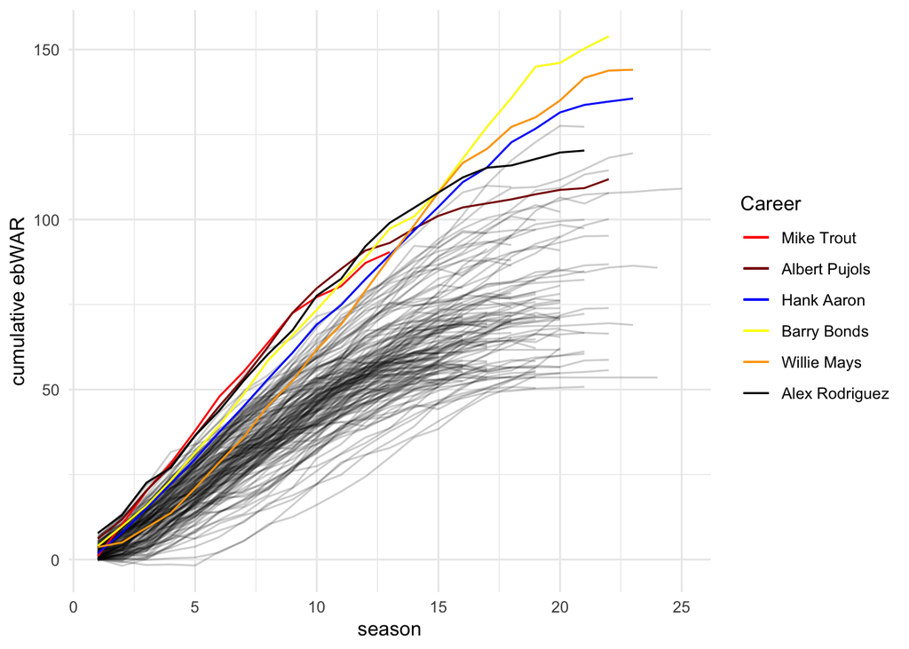

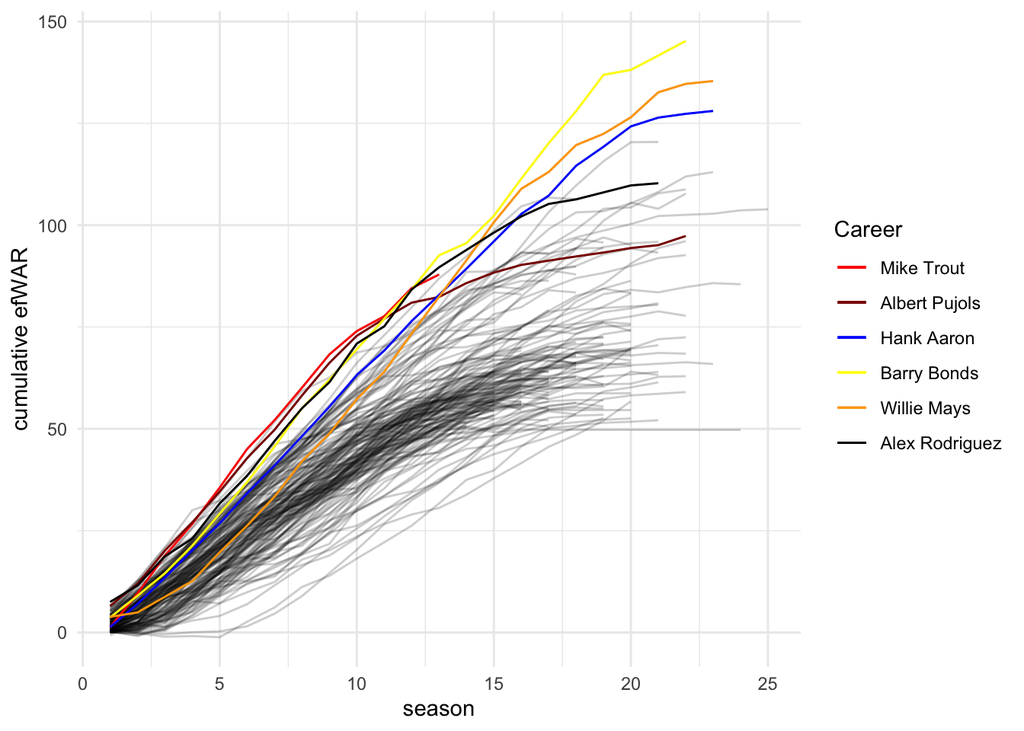

A natural historic comparison for Mike Trout is Mickey Mantle. Both players are amazing all-around athletes, complete hitters, and play center field. Even one of Trout’s nicknames, the Millville Meteor, is an homage to Mantle’s nickname, the Commerce Comet. By raw, unadjusted, statistics Mickey Mantle is viewed as one of the greatest talents of all-time. Mike Trout has been better than Mickey Mantle so far by era-adjusted statistics.

**First 13 seasons aggregated:**

| name | PA | AB | H | HR | BB | BA | OBP | ABpHR | ebWAR | efWAR | ebWARpPA | efWARpPA |
| --- | --- | --- | --- | --- | --- | --- | --- | --- | --- | --- | --- | --- |
| Mickey Mantle | 7536 | 6261 | 1947 | 389 | 1233 | 0.311 | 0.423 | 16.10 | 81.85 | 79.16 | 7.06 | 6.83 |
| Mike Trout | 7121 | 5764 | 1816 | 355 | 1203 | 0.315 | 0.438 | 16.24 | 90.43 | 87.87 | 8.25 | 8.02 |

Maybe Willie Mays is a better comparison for Trout. Below, we see that Trout is comparable to Willie Mays.

**First 13 seasons aggregated:**

| name | PA | AB | H | HR | BB | BA | OBP | ABpHR | ebWAR | efWAR | ebWARpPA | efWARpPA |
| --- | --- | --- | --- | --- | --- | --- | --- | --- | --- | --- | --- | --- |
| Willie Mays | 8137 | 7176 | 2282 | 370 | 873 | 0.318 | 0.391 | 19.39 | 98.31 | 91.37 | 7.85 | 7.30 |
| Mike Trout | 7121 | 5764 | 1816 | 355 | 1203 | 0.315 | 0.438 | 16.24 | 90.43 | 87.87 | 8.25 | 8.02 |

To catch Mays, Trout will have to stay healthy and productive. Mays’ remaining era-adjusted seasons are very good so it is a tall order for Trout to catch him.

| name | PA | AB | H | HR | BB | BA | OBP | ABpHR | ebWAR | efWAR | ebWARpPA | efWARpPA |
| --- | --- | --- | --- | --- | --- | --- | --- | --- | --- | --- | --- | --- |
| Willie Mays | 4677 | 3975 | 1193 | 207 | 655 | 0.3 | 0.399 | 19.2 | 45.77 | 44.02 | 6.36 | 6.12 |

As it stands right now Mike Trout has been the most productive batter on a rate basis in baseball history according to our era-adjusted versions of WAR.

## Max Scherzer

Max Scherzer is one of this era’s greatest pitchers. He is one of a handful of pitchers to win 3 Cy Young awards. Other players with 3 Cy Young awards include Roger Clemens, Randy Johnson, Greg Maddux, Steve Carlton, Tom Seaver, Pedro Martinez, Clayton Kershaw, Justin Verlander, Sandy Koufax, and Jim Palmer. Scherzer’s run from 2013-2019 is especially dominant. Over that stretch he collected his Cy Young awards and never fell below fifth in the voting. That being said, his numbers over that stretch [do not leap off of the page](https://www.fangraphs.com/players/max-scherzer/3137/stats?position=P). Sure, his strikeout rates and strike outs per walk ratios are all-time elite, but ERA and most counting totals do not reflect the Cy Young voting when viewed from the lens of baseball history. Take Tom Seaver as an example. From 1969 to 1975 Terrific Tom boasted similar dominance and also collected 3 Cy Young awards. In 1971 Seaver had a 1.76 ERA over 286.1 innings. [Surely his run leaps off the page](https://www.fangraphs.com/players/tom-seaver/1011708/stats?position=P).

Max Scherzer’s dominance is punished by his era, a time period with a large MLB eligible talent pool, lower innings totals, and a balance of hitting and pitching that was [tilted in the favor of pitching](https://www.espn.com/mlb/story/_/id/12842711/mlb-hurlers-rise-dominance) which, in this case, led to a crowded field of low ERA totals. Our per season era-adjusted statistics paint a much more favorable comparison of Scherzer’s dominant 7-year run from 2013-2019 to that of Seaver’s dominant run from 1969-1975. These players’ primes are nearly identical:

| name | ERA | IP | K | K9 | ebWAR | efWAR | ebWARpIP | efWARpIP |
| --- | --- | --- | --- | --- | --- | --- | --- | --- |
| Max Scherzer | 2.58 | 1855 | 1915 | 9.3 | 51.79 | 48.34 | 6.98 | 6.51 |
| Tom Seaver | 2.60 | 1720 | 1618 | 8.5 | 49.67 | 43.52 | 7.22 | 6.33 |

As it currently stands Max Scherzer ranks 12th in career ebWAR and 15th in career efWAR among pitchers and is among elite company:

| rank | name | ebWAR | rank | name | efWAR |
| --- | --- | --- | --- | --- | --- |
| 7 | Bert Blyleven | 97.69 | 10 | Walter Johnson | 91.80 |
| 8 | Phil Niekro | 94.37 | 11 | Cy Young | 91.28 |
| 9 | Clayton Kershaw | 93.78 | 12 | Tom Seaver | 90.78 |
| 10 | Walter Johnson | 91.53 | 13 | Clayton Kershaw | 88.83 |
| 11 | Warren Spahn | 91.20 | 14 | Don Sutton | 82.98 |
| 12 | Max Scherzer | 90.63 | 15 | Max Scherzer | 82.14 |
| 13 | Zack Greinke | 90.23 | 16 | Pedro Martinez | 82.13 |
| 14 | Gaylord Perry | 89.50 | 17 | Zack Greinke | 80.28 |
| 15 | Steve Carlton | 88.70 | 18 | Mike Mussina | 80.08 |
| 16 | Pedro Martinez | 87.20 | 19 | John Smoltz | 79.36 |
| 17 | Nolan Ryan | 86.85 | 20 | Pete Alexander | 77.55 |

As you see above, similar analyses can point out the dominance of Scherzer’s contemporaries: Clayton Kershaw, Justin Verlander, and Zack Greinke.

## CC Sabathia

CC Sabathia retired in 2019 with 251 wins, over 3000 strikeouts, 62.3 bWAR and 66.5 fWAR. These are great numbers but are somewhat underwhelming in discussions of all-time pitchers in the Hall of Fame. Sabathia fell short of 300 wins and his career bWAR total is tied for 163rd all-time. Our era-adjusted statistics are much more favorable to Sabathia’s career. He ranks 73rd all-time by ebWAR and 64th all-time by efWAR. Below we see that CC Sabathia’s era-adjusted career compares favorable to the era-adjusted careers of some solid Hall of Famers from years past: Pete Alexander, Robin Roberts, Fergie Jenkins, Jim Palmer, and Don Sutton. These careers are sorted by ebWAR per 250 innings pitched (see table below).

Among this group Pete Alexander is currently viewed as an inner circle legend with 373 wins with nearly 120 bWAR and 95.7 fWAR. There is a good chance that if CC Sabathia had been born in the late 1880s and been allowed to play, then we would be viewing Sabathia as one of the key figures in baseball history who would lay the foundation for how to play the game [the right way](https://andscape.com/features/cc-sabathia-on-the-pressure-black-athletes-face-to-play-baseball-the-white-way/).

| name | ERA | IP | K | K9 | ebWAR | efWAR | ebWARpIP | efWARpIP |
| --- | --- | --- | --- | --- | --- | --- | --- | --- |
| Fergie Jenkins | 3.23 | 4199 | 3088 | 6.6 | 77.83 | 75.97 | 4.63 | 4.52 |
| CC Sabathia | 3.15 | 4169 | 2960 | 6.4 | 74.50 | 75.36 | 4.47 | 4.52 |
| Robin Roberts | 3.48 | 4435 | 2494 | 5.1 | 79.01 | 69.39 | 4.45 | 3.91 |
| Jim Palmer | 2.98 | 3688 | 2227 | 5.4 | 65.04 | 52.71 | 4.41 | 3.57 |
| Pete Alexander | 3.31 | 4356 | 2416 | 5.0 | 68.10 | 77.55 | 3.91 | 4.45 |
| Don Sutton | 3.42 | 5071 | 3575 | 6.3 | 72.44 | 82.98 | 3.57 | 4.09 |

CC Sabathia needs to be in the Hall of Fame as soon as he is eligible.

## WAR and it’s usage in HOF discussions

One of the goals of WAR is to provide a framework for people like us to compare players across eras. The following passage is taken directly from the [What is WAR? page on FanGraphs](https://library.fangraphs.com/misc/war/): “The goal of WAR is to provide a holistic metric of player value that allows for comparisons across team, league, year, and **era** and a framework for player evaluation.”

The work in this article moves WAR closer to its goal of providing fair comparisons of players who have played in vastly different eras. This matters when we evaluate a player’s career in historical context. **The HOF players of the old past are beneficiaries of biased performance metrics.** Comparisons based upon “vs your peers” statistics are therefore slanted in favor of old time players—specifically those who performed in the segregated NL/AL. With the Full House Model, this is no more. Here is a look at active players and retired players who are not in the HOF who have era-adjusted bWAR and fWAR values in the top 100 all-time at the time that this was written:

| rank | name | ebWAR | rank | name | efWAR |
| --- | --- | --- | --- | --- | --- |
| 1 | Barry Bonds | 153.89 | 1 | Barry Bonds | 145.24 |
| 2 | Roger Clemens | 145.88 | 2 | Roger Clemens | 141.25 |
| 6 | Alex Rodriguez | 120.29 | 8 | Alex Rodriguez | 110.30 |
| 10 | Albert Pujols | 111.86 | 18 | Albert Pujols | 97.34 |
| 18 | Justin Verlander | 100.23 | 23 | Justin Verlander | 95.07 |
| 30 | Clayton Kershaw | 93.78 | 34 | Clayton Kershaw | 88.83 |
| 36 | Max Scherzer | 90.63 | 36 | Mike Trout | 87.87 |
| 37 | Mike Trout | 90.43 | 39 | Pete Rose | 85.49 |
| 38 | Zack Greinke | 90.23 | 45 | Max Scherzer | 82.14 |
| 48 | Pete Rose | 85.84 | 48 | Miguel Cabrera | 80.41 |
| 51 | Miguel Cabrera | 82.29 | 49 | Zack Greinke | 80.28 |
| 52 | Curt Schilling | 82.09 | 57 | Curt Schilling | 77.00 |
| 59 | Lou Whitaker | 78.39 | 64 | CC Sabathia | 75.36 |
| 60 | Carlos Beltrán | 78.14 | 68 | Carlos Beltrán | 74.26 |
| 73 | CC Sabathia | 74.50 | 75 | Lou Whitaker | 71.22 |
| 79 | Joey Votto | 72.69 | 80 | Bobby Grich | 70.27 |
| 80 | Manny Ramirez | 72.64 | 82 | Rafael Palmeiro | 69.78 |
| 81 | Rafael Palmeiro | 72.57 | 84 | Dwight Evans | 69.40 |
| 82 | Bobby Grich | 72.45 | 87 | Rick Reuschel | 69.12 |
| 89 | Dwight Evans | 71.60 | 88 | Graig Nettles | 68.90 |
| 91 | Chase Utley | 71.33 | 91 | Manny Ramirez | 68.17 |
| 92 | Graig Nettles | 71.01 | 93 | Ichiro Suzuki | 67.82 |
| 94 | Ichiro Suzuki | 70.66 | 94 | Joey Votto | 67.80 |
| 98 | Rick Reuschel | 70.12 | 96 | Chase Utley | 67.73 |

We realize that some of the names on the above list, namely Barry Bonds who had the greatest career ever by ebWAR and efWAR, are not the most popular of figures in baseball history. But is PED usage and personal foibles worse than Cap Anson who played a [major role in establishing racial segregation](https://en.wikipedia.org/wiki/Cap_Anson)? Our era-adjusted stats can be used to evaluate Bonds and Anson in the same contextual environment after accounting for the quality of their respective MLB eligible populations. Below is a direct comparison of Anson’s career and Bonds’s career through 1998 ([the last year that Bonds may have been clean](https://www.espn.com/mlb/story/_/id/32806209/barry-bonds-roger-clemens-far-less-great-subtract-ped-factor)). It’s no comparison.

| name | PA | AB | H | HR | BB | BA | OBP | ABpHR | ebWAR | efWAR | ebWARpPA | efWARpPA |
| --- | --- | --- | --- | --- | --- | --- | --- | --- | --- | --- | --- | --- |
| Barry Bonds | 8313 | 6812 | 1988 | 369 | 1383 | 0.292 | 0.412 | 18.46 | 97.33 | 92.59 | 7.61 | 7.24 |
| Cap Anson | 13927 | 12883 | 3605 | 165 | 1019 | 0.280 | 0.334 | 78.08 | 46.87 | 42.02 | 2.19 | 1.96 |

Our era-adjusted statistics reveal that Cap Anson is more like Nick Markakis than Barry Bonds through 1998 as far as on-field production is concerned. Morevoer, Ty Cobb, who also is a controversial figure, at least has the on-field production to warrant HOF status. Perhaps Anson would remain in the HOF for having well over 3000 hits, but he is no where near the player that Ty Cobb was or that Barry Bonds was through 1998. Anson is Nick Markakis with more longevity and less plate discipline.

| name | PA | AB | H | HR | BB | BA | OBP | ABpHR | ebWAR | efWAR | ebWARpPA | efWARpPA |
| --- | --- | --- | --- | --- | --- | --- | --- | --- | --- | --- | --- | --- |
| Cap Anson | 13927 | 12883 | 3605 | 165 | 1019 | 0.280 | 0.334 | 78.08 | 46.87 | 42.02 | 2.19 | 1.96 |
| Nick Markakis | 9446 | 8280 | 2413 | 182 | 1042 | 0.291 | 0.371 | 45.49 | 46.57 | 41.30 | 3.20 | 2.84 |
| Ty Cobb | 12721 | 11659 | 3726 | 247 | 971 | 0.320 | 0.376 | 47.20 | 114.48 | 108.77 | 5.85 | 5.56 |

## Mark Buehrle

| name | ERA | IP | K | K9 | ebWAR | efWAR | ebWARpIP | efWARpIP |
| --- | --- | --- | --- | --- | --- | --- | --- | --- |
| Mark Buehrle | 3.15 | 3774 | 1906 | 4.5 | 70.33 | 59.47 | 4.66 | 3.94 |
| Jim Palmer | 2.98 | 3688 | 2227 | 5.4 | 65.04 | 52.71 | 4.41 | 3.57 |
| Bob Feller | 3.38 | 3472 | 3104 | 8.0 | 50.50 | 53.21 | 3.64 | 3.83 |
| Whitey Ford | 2.97 | 3161 | 2000 | 5.7 | 49.44 | 49.25 | 3.91 | 3.90 |

Mark Buehrle also has a World Series ring and two no-hitters, including a perfect game, to complement a career that, according to era-adjusted WAR, has been comparable to several currently unquestioned Hall of Fame pitchers. So, besides not having an era-adjustment tool until now, what is the knock against him? It seems that Buehrle is viewed as a [durable compiler](https://www.overtimeheroics.net/2021/03/05/mlb-history-mark-buehrle/) and not a truly great pitcher. The issue against Buehrle is that he was a durable compiler during a period in which pitching usage is much less than past eras. Thus, his innings totals did not really amount to anything impressive. However, when you compare innings “vs your peers” then this story changes. Buehrle’s era-adjusted 3774 innings ranks 34th all-time.

## Luis Tiant

Tiant spent 15 years on the BBWAA ballot and was never particularly close to the 75% voting threshold that was needed for HOF inclusion. He also was not very close to HOF inclusion when his name appeared on the ballot of various Veterans Committees. We would like to revisit Tiant’s HOF case here. By ebWAR and efWAR Tiant ranks as the 42nd and 81st best pitcher in history and ranks 148th and 247th overall among both pitchers and hitters by, respectively, ebWAR and efWAR. There are currently 270 former MLB players in the HOF. If we included players based on stats, then Tiant would be in.

| name | ERA | IP | K | K9 | ebWAR | efWAR | ebWARpIP | efWARpIP |
| --- | --- | --- | --- | --- | --- | --- | --- | --- |
| Luis Tiant | 3.31 | 3313 | 2402 | 6.5 | 61.14 | 50.44 | 4.61 | 3.81 |
| Jim Palmer | 2.98 | 3688 | 2227 | 5.4 | 65.04 | 52.71 | 4.41 | 3.57 |
| Whitey Ford | 2.97 | 3161 | 2000 | 5.7 | 49.44 | 49.25 | 3.91 | 3.90 |
| Bob Feller | 3.38 | 3472 | 3104 | 8.0 | 50.50 | 53.21 | 3.64 | 3.83 |

## Joe Posnanski’s The Baseball 100

Recently Joe Posnanski produced a [book of the 100 greatest players of all time](https://www.simonandschuster.com/books/The-Baseball-100/Joe-Posnanski/9781982180584). This book is elegant in its presentation and is a tour-de-force of great anecdotes, and it is an impressive achievement to have devised such an overall great list without advanced statistical methodology. While at the Athletic, [Posnanski had this to say](https://theathletic.com/1457115/2019/12/17/the-baseball-100-a-project-celebrating-the-greatest-players-in-history/) about his philosophy on ranking lists of these sort: Some of it is science, but admittedly some of it also art. I [Joe Posnanski] will give you a handful of guiding principles:

> 1. I think today’s players tend to be underrated compared to those who came before them.
> 2. I lean toward players who were great at their peak, even if that peak only lasted a short time, and lean away from those who were consistently but not toweringly good for a long time.
> 3. I lean toward players who did multiple things well over specialists (no matter how great) who basically did just one thing well.
> 4. I take a lot of care to make educated guesses about players whose careers were shortened by things beyond their control – World War II, for example, or baseball’s tragic and infuriating color line. I don’t make the same adjustment for injuries. As Bill James has written, there’s a big difference. The years when Joe DiMaggio or Ted Williams or Bob Feller were at war, the years when Josh Gibson and Oscar Charleston played in the Negro Leagues, they were still the best players on earth. They just couldn’t play in the big leagues because of larger issues. When players get hurt – take Don Mattingly, for example, and his back problems – they stop being the best players in the world. I wish Donnie Baseball didn’t get hurt, we all do, but he did, and he was never quite the same player after that. That’s not the same as saying that Bob Feller lost four years when he was still the best pitcher on earth.

We provide Posnanski’s top 25 NL/AL players of all-time along with our top 25 NL/AL players ranked by era-adjusted bWAR and era-adjusted fWAR.

| rank | Posnanski’s NL/AL rankings | ebWAR | efWAR |
| --- | --- | --- | --- |
| 1 | Willie Mays | Barry Bonds | Barry Bonds |
| 2 | Babe Ruth | Roger Clemens | Roger Clemens |
| 3 | Barry Bonds | Willie Mays | Willie Mays |
| 4 | Hank Aaron | Babe Ruth | Henry Aaron |
| 5 | Ted Williams | Henry Aaron | Greg Maddux |
| 6 | Walter Johnson | Alex Rodriguez | Babe Ruth |
| 7 | Ty Cobb | Stan Musial | Stan Musial |
| 8 | Stan Musial | Ty Cobb | Alex Rodriguez |
| 9 | Mickey Mantle | Greg Maddux | Randy Johnson |
| 10 | Honus Wagner | Albert Pujols | Ty Cobb |
| 11 | Roger Clemens | Randy Johnson | Nolan Ryan |
| 12 | Lou Gehrig | Mike Schmidt | Ted Williams |
| 13 | Alex Rodriguez | Rickey Henderson | Mike Schmidt |
| 14 | Rogers Hornsby | Ted Williams | Rickey Henderson |
| 15 | Tris Speaker | Tom Seaver | Bert Blyleven |
| 16 | Mike Schmidt | Lefty Grove | Steve Carlton |
| 17 | Frank Robinson | Tris Speaker | Lefty Grove |
| 18 | Joe Morgan | Justin Verlander | Albert Pujols |
| 19 | Lefty Grove | Joe Morgan | Joe Morgan |
| 20 | Albert Pujols | Frank Robinson | Frank Robinson |
| 21 | Rickey Henderson | Mel Ott | Mel Ott |
| 22 | Pete Alexander | Bert Blyleven | Tris Speaker |
| 23 | Mike Trout | Cal Ripken Jr | Justin Verlander |
| 24 | Randy Johnson | Rogers Hornsby | Gaylord Perry |
| 25 | Eddie Collins | Lou Gehrig | Rogers Hornsby |

We appreciate that Posnanski used an artistic as well as a scientific process to come up with the above rankings. And we appreiacte his thinking that today’s players are underrated compared to those who came before them. We love that Posnanski placed Willie Mays in front of Babe Ruth! We also applaud Posnanski’s effort to include great Negro League players in the upper echelon of his rankings, and we think that he has progressed the conversation on the greatness of Negro League players forward. For reference, Posnanski had Oscar Charleston at #5, Satchel Paige at #10, Josh Gibson at #15, and Pop Lloyd at #25. We removed these players from consideration so that we can make an apples-to-apples comparison between his methodology and our methodology, and we apologize to Posnanski because removing these names changes his list in a way that lowers its artistic value. All-in-all this ranking list is a great achievement.

Now come our criticisms. Whatever reasoning led to putting Willie Mays ahead of Babe Ruth should have also placed Albert Pujols ahead of Lou Gehrig, Cal Ripken Jr. ahead of Honus Wagner, and both Randy Johnson and Greg Maddux ahead of Walter Johnson and Pete Alexander. However, a strong argument can be made for placing Lefty Grove higher than Greg Maddux and Randy Johnson.

We also observe that Posnanski’s list contains 6 NL/AL players who began their career before integration in his top 10 list, and 12 such players who began their career before integration in his top 25 list. By our calculations, the chance of observing 12 or more pre-integration players in a top 25 list is around 1 in 57, and the chance of observing 6 or more pre-integration players in a top 10 list is around 1 in 38. Thus, Posnanski has maybe included too many old time players in his rankings of the greatest all-time players despite his efforts to not do this.

Joey Votto, if you are reading this, then we would like to let you know that our era-adjustment methodology ranks you in the top 100 by both versions of eWAR. [You do not need to wait for Posnanski to come around!](https://www.youtube.com/watch?v=ODSJRvQA1pU&t=1955s) You are also fourth all-time in era-adjusted career OBP, ahead of Babe Ruth, Mickey Mantle, and Lou Gehrig.

We will wrap up our discussion of Posnanski’s work with a connection between his thought process and our mathematical-based approach. Posnanski states that when viewing players [all you can really do is look at the impact a player has in their own time and how much can one appreciate that impact](https://www.youtubetrimmer.com/view/?v=ODSJRvQA1pU&start=1517&end=1525&loop=0). This is exactly what our era-adjustment strategy is. Our method is an assessment of how a player performed vs their peers balanced with the size of the MLB eligible population at the time the player played. Our method formalizes impact in a player’s own time and how much we ought to appreciate that impact.

## A comparison with two respectable internet lists

One consistent theme of our work is that there are not many ranking lists that appropriately compare players across eras. However, there are two lists that we found which do a respectable job by employing methodology which alters WAR to arrive at an era-adjusted version of WAR. These lists are provided by:

1. [Baseball Egg](https://baseballegg.com/all-time-player-rankings/top-100-players-in-baseball-history/): One can see their methodology [here](https://baseballegg.com/how-we-ranked-baseballs-greatest-players/).
2. [The 100 Greatest](https://www.the100greatest.com/2021/02/07/the-100-greatest-baseball-players-of-all-time/): One can see their methodology [here](https://www.the100greatest.com/2021/02/10/making-the-cut-baseball/).

Both of these lists give considerations for a player’s prime seasons. Thus we compare our JAWS rankings to these lists, see below (note that Negro League players are not considered here):

| rank | Baseball Egg | The 100 Greatest | ebJAWS | efJAWS |
| --- | --- | --- | --- | --- |
| 1 | Willie Mays | Barry Bonds | Barry Bonds | Roger Clemens |
| 2 | Ted Williams | Babe Ruth | Roger Clemens | Barry Bonds |
| 3 | Babe Ruth | Willie Mays | Willie Mays | Willie Mays |
| 4 | Hank Aaron | Roger Clemens | Babe Ruth | Babe Ruth |
| 5 | Mickey Mantle | Lou Gehrig | Henry Aaron | Henry Aaron |
| 6 | Rickey Henderson | Randy Johnson | Alex Rodriguez | Greg Maddux |
| 7 | Stan Musial | Hank Aaron | Stan Musial | Randy Johnson |
| 8 | Ty Cobb | Ted Williams | Randy Johnson | Alex Rodriguez |
| 9 | Albert Pujols | Greg Maddux | Albert Pujols | Stan Musial |
| 10 | Joe Morgan | Alex Rodriguez | Greg Maddux | Ted Williams |
| 11 | Barry Bonds | Mike Schmidt | Mike Schmidt | Mike Schmidt |
| 12 | Rogers Hornsby | Albert Pujols | Lefty Grove | Lefty Grove |
| 13 | Mike Schmidt | Ty Cobb | Ted Williams | Ty Cobb |
| 14 | Walter Johnson | Clayton Kershaw | Ty Cobb | Rickey Henderson |
| 15 | Greg Maddux | Mike Trout | Rickey Henderson | Steve Carlton |
| 16 | Mike Trout | Pedro Martinez | Justin Verlander | Nolan Ryan |
| 17 | Cal Ripken Jr | Justin Verlander | Joe Morgan | Albert Pujols |
| 18 | Lou Genrig | Rogers Hornsby | Tom Seaver | Justin Verlander |
| 19 | Tom Seaver | Mickey Mantle | Cal Ripken Jr | Joe Morgan |
| 20 | Honus Wagner | Stan Musial | Mike Trout | Bert Blyleven |
| 21 | Carl Yastrzemski | Walter Johnson | Rogers Hornsby | Rogers Hornsby |
| 22 | Frank Robinson | Lefty Grove | Lou Gehrig | Mike Trout |
| 23 | Randy Johnson | Mariano Rivera | Wade Boggs | Mickey Mantle |
| 24 | Eddie Collins | Max Scherzer | Clayton Kershaw | Cal Ripken Jr |
| 25 | Wade Boggs | Jimmie Foxx | Mickey Mantle | Lou Gehrig |

At a cursory glance these lists as very similar in that they all include a large amount of players that began their careers after baseball was integrated. Counts of players who began their career before baseball was integrated are below:

|  | Baseball Egg | The 100 Greatest | ebJAWS | efJAWS |  |
| --- | --- | --- | --- | --- | --- |
| top 10 | 4 | 3 | 2 | 3 |  |
| top 25 | 9 | 9 | 7 | 7 |  |

And here are corresponding measures of agreement with how these lists conform with what is expected assuming our MLB-eligible population is calculated correctly, and that baseball talent is evenly distributed across time. This measure of agreement is in the form of a chance that one could observe $x$ names in a top 10 or top 25 list who started their before baseball was integrated. A chance closer to 1 in 1 is better than a chance that is far away from 1 in 1. A chance of 1 in 1 means that the list gives under question would be in perfect agreement with what is statistically expected.

[output not shown]

These lists all avoid very problematic preferential treatment of players from the past. That being said, our era-adjusted versions of JAWS provides representation of older era players that is closer in alignment to what is statistically expected than either Baseball Egg or The 100 Greatest. It is worth noting that Baseball Egg makes additional adjustments for PEDs and players whose careers were cut short due to war. We applaud these adjustments but ultimately think that they went a tad too far.

## ESPN’s Top 100 MLB players of all time

In February 2022, [ESPN published a new top 100 ranking list](https://www.espn.com/mlb/story/_/id/33145121/top-100-mlb-players-all). Their list was compiled in essentially two steps. As quoted from the linked article:

> First, they selected a pool of 200 candidate players using career WAR, Hall of Fame status, peak performance and overall contributions to the game as initial screening criteria. They then asked dozens of ESPN editors and writers to contribute to a balloting system that pits players from the list against each other in head-to-head voting. The question they posed: “Based on a combination of career value and peak performance, which player would you rank higher?” ESPN’s participants voted more than 20,000 times. Based on those votes, the players were ranked by the percentage of the time they were chosen over any competing player.

| name | PA | AB | H | HR | BB | BA | OBP | ABpHR | ebWAR | efWAR | ebWARpPA | efWARpPA |
| --- | --- | --- | --- | --- | --- | --- | --- | --- | --- | --- | --- | --- |
| Mel Ott | 11058 | 9370 | 2655 | 418 | 1624 | 0.283 | 0.393 | 22.42 | 99.74 | 95.72 | 5.86 | 5.63 |
| Tony Gwynn | 10448 | 9560 | 3270 | 104 | 779 | 0.342 | 0.390 | 91.92 | 70.53 | 65.45 | 4.39 | 4.07 |

The differences in evaluating Mel Ott’s career and Tony Gwynn’s career between this version of our work and the previous version likely rests with how the MLB eligible populations are calculated and how careers are evaluated. The previous calculation of the MLB eligible population under counted eligible individuals during the days that Mel Ott played when compared with our current [calculation of the MLB eligible population](https://htmlpreview.github.io/?https://github.com/ecklab/era-adjustment-app-supplement/blob/main/MLBeligiblepop.html) based on player demographic data. The previous version also compared careers by evaluating their performances as if everyone individually started playing in 1977. This method had some instability. For example, this method made no corrections for the strike shortened 1981 season. Our current version constructs a common environment from all non-strike NL seasons from 1977-1989, similar to what was done in [Michael Schell’s work](https://www.amazon.com/Baseballs-All-Time-Hitters-Michael-Schell/dp/0691004552).

## Christina Kahrl

In 2016 [Christina Kahrl wrote an excellent article](https://www.espn.com/mlb/story/_/page/mlbrank100_wagnergehrig/mlbrank-exploring-greatness-honus-wagner-lou-gehrig) on problems with using poorly calibrated “vs your peers” statistics to compare players across eras. Specifically, she said:

> The Gehrig and Wagner arguments boil down to this: Via WAR or OPS+ or your own understanding of all of the numbers we have, you have faith in our measuring their relative extraordinary superiority over their peers in smaller leagues with deliberate personnel limitations and an uneven distribution of talent. You can have that faith, and it relies on a lot of data for support – at the same time that you turn a blind eye to what’s going on in the game that creates that data.

This is a point that is routinely missed among baseball fans and analysts alike, in part because they have been duped by websites claiming that the metrics they use are era-adjusted. **For a metric to be era-adjusted it needs to account for the changing distributions of league statistics and the changing composition of MLB players.** Returning to Kahrl’s point about Lou Gehrig and Honus Wagner, the Full House Model ranks modern first basemen and shortstops above Gehrig and Wagner in career ebWAR and career efWAR.

| name | PA | AB | H | HR | BB | BA | OBP | ABpHR | ebWAR | efWAR | ebWARpPA | efWARpPA |
| --- | --- | --- | --- | --- | --- | --- | --- | --- | --- | --- | --- | --- |
| Albert Pujols | 13201 | 11432 | 3522 | 662 | 1523 | 0.308 | 0.391 | 17.27 | 111.86 | 97.34 | 5.51 | 4.79 |
| Lou Gehrig | 9569 | 8096 | 2502 | 479 | 1428 | 0.309 | 0.415 | 16.90 | 95.87 | 92.98 | 6.51 | 6.32 |

| name | PA | AB | H | HR | BB | BA | OBP | ABpHR | ebWAR | efWAR | ebWARpPA | efWARpPA |
| --- | --- | --- | --- | --- | --- | --- | --- | --- | --- | --- | --- | --- |
| Alex Rodriguez | 11917 | 10293 | 3047 | 547 | 1338 | 0.296 | 0.383 | 18.82 | 120.29 | 110.30 | 6.56 | 6.02 |
| Cal Ripken Jr | 13088 | 11766 | 3263 | 370 | 1129 | 0.277 | 0.341 | 31.80 | 97.39 | 93.24 | 4.84 | 4.63 |
| Honus Wagner | 10815 | 10175 | 2927 | 246 | 523 | 0.288 | 0.330 | 41.36 | 86.46 | 89.81 | 5.20 | 5.40 |

It is worth noting that Gehrig and Wagner are more competitive when evaluating their careers on a rate basis. Some of this is due to Pujols, A Rod, and Ripken Jr having longer era-adjusted careers than either Gehrig or Wagner. The comparisons below consider Pujols from 2001-2015, A Rod from 1994-2012, and Ripken Jr from 1981-1996. This viewing of careers has Gehrig and Pujols in a near tie, same as Wagner and Ripken Jr. That being said, our era-adjusted JAWS metrics rank Albert Pujols above Lou Gehrig and Cal Ripken Jr above Honus Wagner. And Alex Rodriguez is clearly better than Honus Wagner by all approaches mentioned here (career, shortened career, and JAWS).

| name | PA | AB | H | HR | BB | BA | OBP | ABpHR | ebWAR | efWAR | ebWARpPA | efWARpPA |
| --- | --- | --- | --- | --- | --- | --- | --- | --- | --- | --- | --- | --- |
| Albert Pujols | 9813 | 8380 | 2687 | 546 | 1242 | 0.321 | 0.410 | 15.35 | 101.07 | 88.35 | 6.69 | 5.85 |
| Lou Gehrig | 9569 | 8096 | 2502 | 479 | 1428 | 0.309 | 0.415 | 16.90 | 95.87 | 92.98 | 6.51 | 6.32 |

| name | PA | AB | H | HR | BB | BA | OBP | ABpHR | ebWAR | efWAR | ebWARpPA | efWARpPA |
| --- | --- | --- | --- | --- | --- | --- | --- | --- | --- | --- | --- | --- |
| Alex Rodriguez | 10791 | 9339 | 2794 | 507 | 1185 | 0.299 | 0.384 | 18.42 | 115.25 | 105.22 | 6.94 | 6.34 |
| Cal Ripken Jr | 10564 | 9430 | 2642 | 322 | 986 | 0.280 | 0.348 | 29.29 | 91.73 | 87.80 | 5.64 | 5.40 |
| Honus Wagner | 10815 | 10175 | 2927 | 246 | 523 | 0.288 | 0.330 | 41.36 | 86.46 | 89.81 | 5.20 | 5.40 |

## Ted Williams

In a [previous article](https://community.fangraphs.com/challenging-war-and-other-statistics-as-era-adjustment-tools/), Eck devoted attention to Ted Williams with a focus on how his career would be much worse in an era-neutral context. While Williams’s stats do take a huge hit as speculated, his era-adjusted career WAR values are still very high. He is also firmly in the top 10 on a rate basis, as seen above.

Considering that Ted Williams missed a large part of five seasons due to wars, it is reasonable to include Ted Williams on the “Mount Rushmore” (top 4) of the greatest all-time baseball players based on this analysis… But there is a lot of context that this current analysis does not yet account for. We currently account for slow integration, talent depletion due to World War II, changing game numbers, and league expansion. But we do not yet account for the general quality of a players’ competition, and Ted Williams did not face very good pitchers.

We now look at the best pitching seasons by ebWAR during the years that Williams did not serve in wars and we remove Williams’s Boston teammates (namely Lefty Grove). What we find is that the top end of his competition is weak in both an absolute sense and relative to the contemporaneous NL. Below are the top 10 AL pitching seasons among non-Williams teammates during the years that Ted Williams played (1939-1960 with 1943-45 and 1952-53 removed).

| name | lg | team | age | year | IP | ER | ERA | K | K9 | ebWAR | efWAR |
| --- | --- | --- | --- | --- | --- | --- | --- | --- | --- | --- | --- |
| Hal Newhouser | AL | DET | 25 | 1946 | 280 | 73 | 2.35 | 285 | 9.2 | 10.45 | 9.62 |
| Bob Feller | AL | CLE | 21 | 1940 | 296 | 87 | 2.65 | 363 | 11.0 | 8.85 | 9.35 |
| Billy Pierce | AL | CHA | 28 | 1955 | 213 | 45 | 1.90 | 187 | 7.9 | 8.06 | 6.91 |
| Early Wynn | AL | CLE | 36 | 1956 | 264 | 72 | 2.45 | 173 | 5.9 | 8.02 | 5.74 |
| Herb Score | AL | CLE | 23 | 1956 | 236 | 61 | 2.33 | 281 | 10.7 | 8.00 | 8.26 |
| Thornton Lee | AL | CHA | 34 | 1941 | 274 | 78 | 2.56 | 174 | 5.7 | 7.72 | 4.79 |
| Bob Feller | AL | CLE | 20 | 1939 | 274 | 87 | 2.86 | 321 | 10.5 | 7.70 | 6.12 |
| Hoyt Wilhelm | AL | BAL | 36 | 1959 | 221 | 59 | 2.40 | 144 | 5.9 | 7.17 | 3.83 |
| Frank Lary | AL | DET | 28 | 1958 | 264 | 77 | 2.62 | 124 | 4.2 | 6.90 | 4.84 |
| Jim Bunning | AL | DET | 25 | 1957 | 274 | 83 | 2.73 | 192 | 6.3 | 6.89 | 3.88 |

Below are the top 10 NL pitching seasons during the same time period. Recall that interleague play did not exist when Ted Williams played.

| name | lg | team | age | year | IP | ER | ERA | K | K9 | ebWAR | efWAR |
| --- | --- | --- | --- | --- | --- | --- | --- | --- | --- | --- | --- |
| Harry Brecheen | NL | SLN | 33 | 1948 | 242 | 58 | 2.16 | 214 | 8.0 | 9.94 | 8.99 |
| Johnny Antonelli | NL | NY1 | 24 | 1954 | 252 | 60 | 2.14 | 189 | 6.8 | 9.77 | 4.65 |
| Mort Cooper | NL | SLN | 29 | 1942 | 274 | 66 | 2.17 | 217 | 7.1 | 9.71 | 8.82 |
| Ewell Blackwell | NL | CIN | 24 | 1947 | 259 | 68 | 2.36 | 258 | 9.0 | 9.51 | 8.98 |
| Robin Roberts | NL | PHI | 27 | 1954 | 296 | 101 | 3.07 | 204 | 6.2 | 8.95 | 6.45 |
| Ernie Broglio | NL | SLN | 24 | 1960 | 222 | 54 | 2.19 | 194 | 7.9 | 8.73 | 3.97 |
| Warren Spahn | NL | BSN | 26 | 1947 | 280 | 73 | 2.35 | 174 | 5.6 | 8.45 | 6.03 |
| Robin Roberts | NL | PHI | 24 | 1951 | 296 | 99 | 3.01 | 172 | 5.2 | 8.35 | 7.48 |
| Warren Spahn | NL | BSN | 30 | 1951 | 280 | 95 | 3.05 | 203 | 6.5 | 7.74 | 5.13 |
| Johnny Sain | NL | BSN | 30 | 1948 | 296 | 89 | 2.71 | 185 | 5.6 | 7.46 | 4.62 |

The top 10 AL pitching seasons excluding Boston Red Sox players for select 20 year stretches are included below for comparison:

**1961-1980 AL:**

| name | lg | team | age | year | IP | ER | ERA | K | K9 | ebWAR | efWAR |
| --- | --- | --- | --- | --- | --- | --- | --- | --- | --- | --- | --- |
| Ron Guidry | AL | NYA | 27 | 1978 | 259 | 54 | 1.88 | 260 | 9.0 | 10.72 | 9.71 |
| Wilbur Wood | AL | CHA | 29 | 1971 | 282 | 71 | 2.27 | 184 | 5.9 | 10.22 | 6.13 |
| Mark Fidrych | AL | DET | 21 | 1976 | 231 | 50 | 1.95 | 118 | 4.6 | 9.87 | 4.74 |
| Bert Blyleven | AL | MIN | 22 | 1973 | 273 | 72 | 2.37 | 239 | 7.9 | 8.55 | 10.15 |
| Hank Aguirre | AL | DET | 31 | 1962 | 214 | 48 | 2.02 | 150 | 6.3 | 8.53 | 4.67 |
| Wilbur Wood | AL | CHA | 30 | 1972 | 296 | 92 | 2.80 | 144 | 4.4 | 8.01 | 4.48 |
| Gaylord Perry | AL | CLE | 33 | 1972 | 277 | 65 | 2.11 | 182 | 5.9 | 7.98 | 6.62 |
| Gaylord Perry | AL | CLE | 35 | 1974 | 277 | 75 | 2.44 | 203 | 6.6 | 7.91 | 5.04 |
| Bert Blyleven | AL | MIN | 23 | 1974 | 238 | 67 | 2.53 | 246 | 9.3 | 7.67 | 8.28 |
| Dean Chance | AL | LAA | 23 | 1964 | 264 | 70 | 2.39 | 169 | 5.8 | 7.52 | 6.87 |

**1981-2000 AL:**

| name | lg | team | age | year | IP | ER | ERA | K | K9 | ebWAR | efWAR |
| --- | --- | --- | --- | --- | --- | --- | --- | --- | --- | --- | --- |
| Bret Saberhagen | AL | KCA | 25 | 1989 | 296 | 63 | 1.92 | 207 | 6.3 | 12.61 | 9.39 |
| Roger Clemens | AL | TOR | 34 | 1997 | 296 | 74 | 2.25 | 257 | 7.8 | 12.16 | 10.46 |
| Kevin Appier | AL | KCA | 25 | 1993 | 253 | 67 | 2.38 | 178 | 6.3 | 10.22 | 8.21 |
| Roger Clemens | AL | TOR | 35 | 1998 | 266 | 73 | 2.47 | 265 | 9.0 | 10.03 | 8.03 |
| Bert Blyleven | AL | CLE | 30 | 1981 | 242 | 82 | 3.05 | 189 | 7.0 | 9.87 | 5.30 |
| Teddy Higuera | AL | ML4 | 30 | 1988 | 228 | 67 | 2.64 | 189 | 7.5 | 9.12 | 5.51 |
| Frank Viola | AL | MIN | 28 | 1988 | 263 | 79 | 2.70 | 201 | 6.9 | 8.85 | 5.87 |
| Randy Johnson | AL | SEA | 31 | 1995 | 275 | 72 | 2.36 | 362 | 11.8 | 8.82 | 10.31 |
| Dave Stieb | AL | TOR | 26 | 1984 | 296 | 89 | 2.71 | 228 | 6.9 | 8.61 | 6.42 |
| Frank Viola | AL | MIN | 27 | 1987 | 253 | 67 | 2.38 | 192 | 6.8 | 8.51 | 5.50 |

**2001-2019 AL:**

The 2020 season is not included.

| name | lg | team | age | year | IP | ER | ERA | K | K9 | ebWAR | efWAR |
| --- | --- | --- | --- | --- | --- | --- | --- | --- | --- | --- | --- |
| Justin Verlander | AL | DET | 29 | 2012 | 296 | 71 | 2.16 | 255 | 7.8 | 12.22 | 10.40 |
| Zack Greinke | AL | KCA | 25 | 2009 | 266 | 54 | 1.83 | 232 | 7.8 | 11.34 | 9.65 |
| Corey Kluber | AL | CLE | 31 | 2017 | 271 | 54 | 1.79 | 270 | 9.0 | 11.22 | 9.22 |
| Mike Minor | AL | TEX | 31 | 2019 | 269 | 84 | 2.81 | 171 | 5.7 | 10.08 | 4.70 |
| Justin Verlander | AL | DET | 28 | 2011 | 296 | 72 | 2.19 | 257 | 7.8 | 10.03 | 7.79 |
| Corey Kluber | AL | CLE | 28 | 2014 | 276 | 73 | 2.38 | 278 | 9.1 | 9.72 | 7.79 |
| David Price | AL | TBA | 26 | 2012 | 249 | 66 | 2.39 | 191 | 6.9 | 9.06 | 5.02 |
| Lance Lynn | AL | TEX | 32 | 2019 | 266 | 84 | 2.84 | 204 | 6.9 | 8.81 | 6.48 |
| Justin Verlander | AL | DET | 33 | 2016 | 280 | 86 | 2.76 | 227 | 7.3 | 8.59 | 6.10 |
| Justin Verlander | AL | DET | 34 | 2017 | 277 | 89 | 2.89 | 206 | 6.7 | 8.30 | 5.08 |

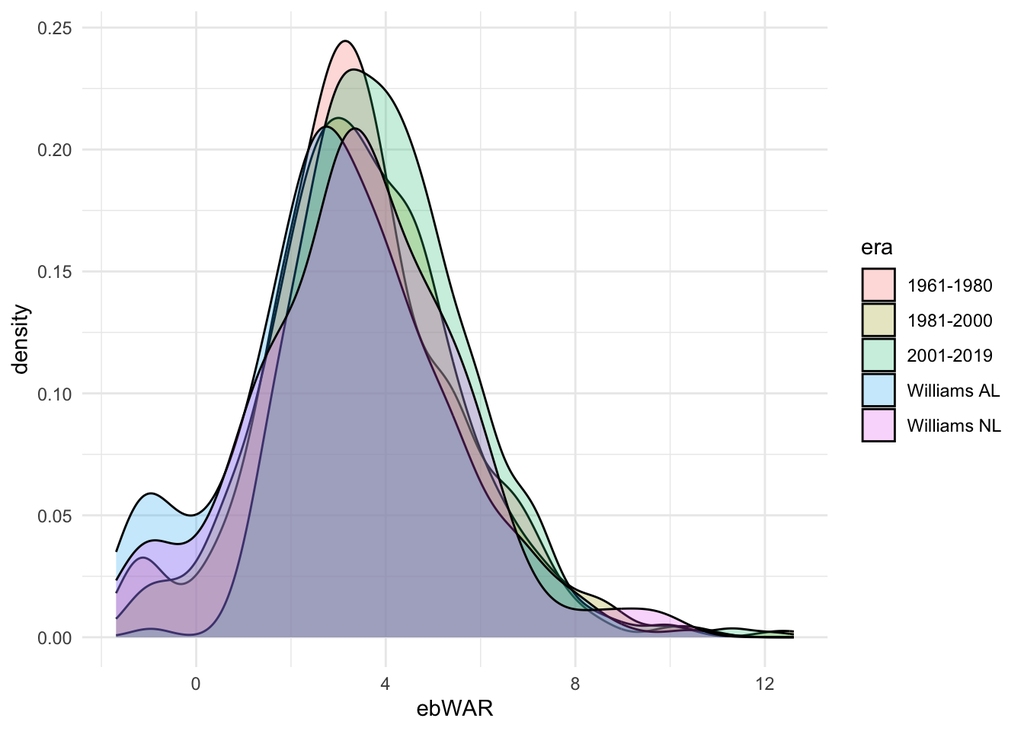

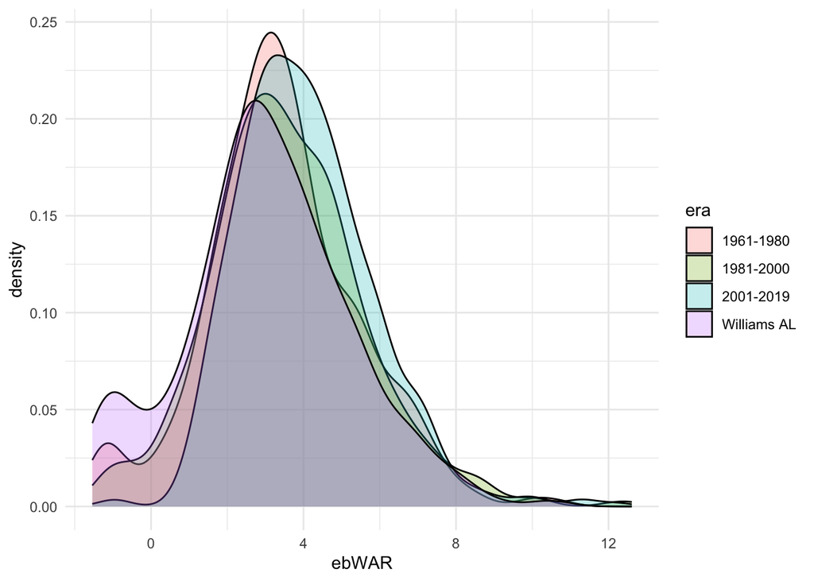

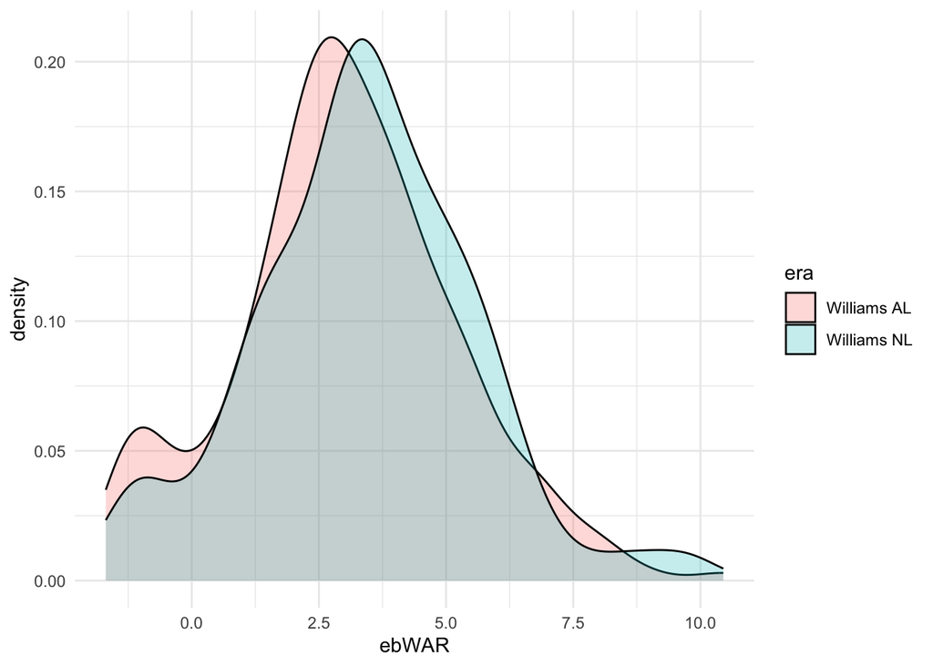

What this shows is that Ted Williams faced some of the weakest competition that one could have faced over a lengthy career. Or, in other words, if you could choose a contextual environment with the goal of maximizing your potential for achieving mythical stats, then the 1939-1960 AL with Lefty Grove on your team would have to be near the top of the list. Moreover, Ted Williams was a left-handed hitter and Lefty Grove was a left-handed pitcher (his real name is not Lefty). This is important because Ted Williams was relatively weak against left-handed pitching. So Ted had it comparatively easier than others.

In addition, Ted Williams faced fewer left handed-hitters than great hitters from more modern eras, and this is something we also have not yet accounted for. Kenneth Matinale has some analyses on this topic, you can view one [here](https://radicalbaseball.blogspot.com/2013/03/ted-williams-lefty-batter-v-lefty.html). Below are Ted Williams splits from baseball reference (the information is not based on complete play-by-play data). We can see that Williams was far worse against left-handed pitchers, and that he faced lefties only 21.8% of the time. On the other hand, Tony Gywnn and George Brett faced lefties, respectively, 34.4% and 33.2% of the time.

Platoon Splits

| Split | PA | AB | H | HR | BB | BA | OBP | SLG | OPS | HBP | SH | SF | tOPS+ |
| --- | --- | --- | --- | --- | --- | --- | --- | --- | --- | --- | --- | --- | --- |
| vs RHP | 7089 | 5548 | 1938 | 414 | 1497 | .349 | .488 | .664 | 1.152 | 26 | 1 | 17 | 106 |
| vs LHP | 1971 | 1620 | 504 | 61 | 334 | .311 | .431 | .496 | .927 | 11 | 1 | 5 | 68 |

Provided by [Baseball-Reference.com](https://www.sports-reference.com/sharing.html?utm_source=direct&utm_medium=Share&utm_campaign=ShareTool): [View Original Table](https://www.baseball-reference.com/players/split.fcgi?id=willite01&year=Career&t=b&utm_source=direct&utm_medium=Share&utm_campaign=ShareTool#plato)  
Generated 12/7/2022.

Below is an educated guess of Ted Williams’s era-adjusted statistics had 33% of his plate appearances came against lefties (denoted Ted Williams*). The table below also provides, for reference, Ted William’s era-adjusted stats in the first row. We use a wOBA based approach to estimate Williams’s era-adjusted WAR had 33% of his plate appearances came against lefties using the run values computed [here](https://web.stanford.edu/class/stats50/files/STATS_50_Derivation_of_the_wOBA.pdf). This reference gives run values for outs (-0.26), walks (0.29), HBP (0.31), singles (0.44), doubles (0.74), triples (1.01), and home runs (1.39). We will suppose that one run is 0.10 WAR (using a [10 runs-to-wins conversion](https://www.baseball-reference.com/about/war_explained_runs_to_wins.shtml)). Note that Williams loses more home runs than hits. We assign a run value of 0.59 for this difference so that theses added hits are halfway between a single and a double. The analysis here shows that Ted Williams’s era-adjusted stats would take a substantial hit if they were additionally adjusted for a more modern pitching deployment strategy, one that was embraced during the time frame that we are using to evaluate careers.

| name | PA | AB | H | HR | BB | BA | OBP | ABpHR | ebWAR | efWAR | ebWARpPA | efWARpPA |
| --- | --- | --- | --- | --- | --- | --- | --- | --- | --- | --- | --- | --- |
| Ted Williams | 10184 | 8258 | 2593 | 503 | 1867 | 0.314 | 0.442 | 16.42 | 107.86 | 107.75 | 6.88 | 6.88 |
| Ted Williams* | 10184 | 8299 | 2576 | 472 | 1824 | 0.31 | 0.436 | 17.58 | 101.36 | 101.25 | 6.47 | 6.46 |

With all this in mind, we are now going to start a speculative exercise on Ted Williams prospects of remaining in the “Mount Rushmore” (top 4) of baseball players as judged by career value if you gave him his 5 seasons back. For this exercise we will remove Alex Rodriguez and Roger Clemens entirely and will consider Bonds stats through 1998 (denoted Barry Bonds**) where the speculative projection of Bonds career is under the premise of what his career would look like had he not taken PEDs after his age 33 season (we will ignore [amphetamine speculation](https://www.baseballprospectus.com/news/article/4740/under-the-knife-amphetamines-and-baseball/) and just focus on PEDs as is standard practice with these types of discussions). This exercise will focus on efWAR since it is favorable to Ted Williams, but we will be using our lefty percentage adjusted version of Ted Williams. Below is the list of all players that have obtained as much efWAR as Ted Williams where Mike Trout (through 2023, his age 31 season) is included in the conversation since he is the greatest player on a rate basis. In aggregate, this is a favorable set of circumstances for Ted Williams.

| name | ebWAR | efWAR |
| --- | --- | --- |
| Willie Mays | 144.08 | 135.39 |
| Henry Aaron | 135.60 | 128.05 |
| Greg Maddux | 113.66 | 120.73 |
| Babe Ruth | 137.98 | 120.28 |
| Stan Musial | 119.51 | 113.03 |
| Randy Johnson | 110.81 | 109.77 |
| Ty Cobb | 114.48 | 108.77 |
| Nolan Ryan | 86.85 | 108.30 |
| Mike Schmidt | 109.58 | 106.41 |
| Rickey Henderson | 109.08 | 103.90 |
| Bert Blyleven | 97.69 | 101.82 |
| Ted Williams* | 101.36 | 101.25 |
| Barry Bonds** | 97.33 | 92.59 |
| Mike Trout | 90.43 | 87.87 |

Where does this go from here? Ted Williams needs only roughly 20 efWAR to eclipse Greg Maddux and Babe Ruth for the 3rd spot (keep in mind that Babe Ruth faced Walter Johnson and performed almost as well [against Lefty Grove](https://www.jmanesaz.com/player-matchup/bat_id/ruthba01/pit_id/grovele01) as Williams did against the anonymous lefties of his day). Barry Bonds who put up 8.41 efWAR [in 1998](https://www.youtube.com/watch?v=xi7IPZAcP78) is slightly behind Ted Williams. Mike Trout is on the outside looking in. But Trout is the most productive player all-time on a rate basis and this analysis is only trough his age 31 season. A close look at Williams’s stats reveal that he got off to a hot start in 1953 and his 1942 and 1946 seasons were amazing. So he could pull this off. But none of this accounts for the relatively poor pitching competition that Ted Williams faced in his time period. How much should that factor in? A 5% reduction? A 10% reduction? More? Less? And how do these types of projections account for injury risk?

It seems like a tall order, albeit it is quite possible, for Ted Williams to crack the Mount Rushmore of career efWAR from the analysis. But this analysis was very favorable to Williams. We considered a favorable metric, ignored Clemens, threw out all post-1998 Bonds stats, and have not adjusted for strength of competition. The same exercise viewed through ebWAR would be harder on him. Ted Williams remains one of the greatest players of all-time. But the mythical lore that surrounds him reflects failed attempts to properly evaluate the historical achievements of players. Ted Williams is Joey Votto with more power and more longevity. Oh the blasphemy

| name | PA | AB | H | HR | BB | BA | OBP | ABpHR | ebWAR | efWAR | ebWARpPA | efWARpPA |
| --- | --- | --- | --- | --- | --- | --- | --- | --- | --- | --- | --- | --- |
| Joey Votto | 9225 | 7470 | 2283 | 283 | 1626 | 0.306 | 0.433 | 26.4 | 72.69 | 67.8 | 5.12 | 4.78 |
| Ted Williams* | 10184 | 8299 | 2576 | 472 | 1824 | 0.31 | 0.436 | 17.58 | 101.36 | 101.25 | 6.47 | 6.46 |

In all, we are skeptical that Ted Williams is in the Mt Rushmore of the game’s all-time greatest players as judged by era-adjusted wins above replacement. We hope that our analysis will shed light on Ted Williams accomplishments. We hope that the reader will see that the real Ted Williams with the lore removed is an all-time great player, just perhaps not Mt Rushmore worthy.